# Examen parcial - Primavera 2021

Alfredo Garbuno Iñigo

**Entrega:**

Enviar por correo electrónico una carpeta comprimida (`equipo-xx.zip`) que incluya datos y codigo de solución a mas tardar el 23 de Marzo antes de las 11:59pm (medianoche). El asunto deberá ser `[MB - 2021] Parcial Equipo XX`, donde reemplazarás `XX` con el codigo de tu equipo. No se aceptarán entregas extemporáneas. Será mejor entregar un examen resuelto parcialmente, que no entregar nada.

**Instrucciones:**

- Tus respuestas deben ser claras y debes explicar los resultados, incluye también tus procedimientos/código de manera ordenada, y el código comentado.
- Se evaluará la presentación de resultados (calidad de las gráficas, tablas, …).
- Las sesiones de dudas del Miércoles 17 de Marzo será completamente para responder dudas del examen. Adicionalmente, en las sesiones del Martes 16 y Jueves 18 se reservará una media hora para dudas (dependerá de la agenda cuál será el momento más oportuno para abrir el espacio).
- No pueden compartir soluciones entre diferentes equipos.
- Al entregar este examen afirmas que el trabajo se realizó sólo con tu compañeros de equipo. El material que utilizaste para apoyarte consistió de las notas en clase (pdfs en Canvas), el código fuente de las notas en el repositorio de Github.
- Al entregar estás dando tu consentimiento para que bajo sospecha y suficiente evidencia de copia se anule tu evaluación.

**Ponderación:**

El examen está compuesto por tres apartados cuyo peso son los siguientes: 1. Datos !Kung San (60%) 2. Datos Vinos (25%) 3. Datos Nettle (15%)

## Datos: !Kung San.

Los datos que tenemos en `Howell.csv` son datos parciales del censo para el área de Dobe, en particular para la población de los [!Kung San.](https://es.wikipedia.org/wiki/!Kung) Éstos fueron recopilados a partir de entrevistas realizadas por Nancy Howell a finales de la década de 1960.

a ) Los pesos presentados a continuación se registraron en el censo !Kung, pero no se registraron las alturas para estas personas. Proporciona predicciones para las alturas e intervalos del 89% para cada uno de estos individuos basados en un modelo de regresión lineal.

### Respuesta:

```r
pesos<-tibble(peso = c(46.95, 43.72, 64.78, 32.59, 54.63))
pesos
```

```
## # A tibble: 5 x 1
##    peso
##   <dbl>
## 1  47.0
## 2  43.7
## 3  64.8
## 4  32.6
## 5  54.6
```

Dado que queremos generar predicciones para las alturas y sólo tenemos los pesos, decidimos utilizar un modelo de regresión lineal bajo un enfoque bayesiano utilizando como variable predictora el peso.

```r
datos1<-read_delim("howell.csv", delim = ";" ) #Cargamos los datos
```

Para lo cual, primero haremos un análisis exploratorio a los datos parciales del censo para conocer más al respecto.

```r
howell<-datos1 #hacemos una copia de los datos originales
head(howell) #imprimimos las primeras observaciones
```

```
## # A tibble: 6 x 4
##   altura  peso  edad genero
##    <dbl> <dbl> <dbl>  <dbl>
## 1   152.  47.8    63      1
## 2   140.  36.5    63      0
## 3   137.  31.9    65      0
## 4   157.  53.0    41      1
## 5   145.  41.3    51      0
## 6   164.  63.0    35      1
```

```r
dim(howell)
```

```
## [1] 544   4
```

```r
howell$genero<-factor(howell$genero) #Convertimos la variable a factor
summary(howell) #generamos resumen de las estadísticas
```

```
##      altura            peso             edad       genero
##  Min.   : 53.98   Min.   : 4.252   Min.   : 0.00   0:287
##  1st Qu.:125.09   1st Qu.:22.008   1st Qu.:12.00   1:257
##  Median :148.59   Median :40.058   Median :27.00
##  Mean   :138.26   Mean   :35.611   Mean   :29.34
##  3rd Qu.:157.48   3rd Qu.:47.209   3rd Qu.:43.00
##  Max.   :179.07   Max.   :62.993   Max.   :88.00
```

Primero identificamos que nuestro conjunto de datos contiene únicamente 544 observaciones y 4 columnas. Donde la variable a predecir (altura) se encuentra en centímetros, el peso en kg, la edad en años y el género es un indicador de sexo masculino cuando toma el valor de 1.

Después vemos que la muestra contiene a personas de 0 a 88 años de edad con pesos que van de los 4 kilos a los 63. Sin embargo, llama nuestra atención que aunque la mediana de altura está alrededor de 1.5 metros, la mediana de la edad corresponde a una persona adulta con 27 años de edad y 40 kg de peso. Para definir la distribución previa de los parámetros, decidimos que no tenemos suficiente conocimiento previo para poder proponerla con un suficiente conocimiento del problema. Debido a ello, utilizamos el default de la distribución que proporciona stan_glm (una distribución poco informativa) para no sesgar nuestro modelo, asumieendo distribuciones previas normales para los coeficientes.

```r
SEED <- 2021 #proponemos una semilla para reproducibilidad
set.seed(SEED)
fit_1a <- stan_glm(altura ~ peso, data = howell, seed=SEED, refresh = 0) #generamos el modelo lineal bayesiano
print(fit_1a) #imprimimos el objeto con el modelo
```

```
## stan_glm
##  family:       gaussian [identity]
##  formula:      altura ~ peso
##  observations: 544
##  predictors:   2
## ------
##             Median MAD_SD
## (Intercept) 75.5    1.0
## peso         1.8    0.0
##
## Auxiliary parameter(s):
##       Median MAD_SD
## sigma 9.4    0.3
##
## ------
## * For help interpreting the printed output see ?print.stanreg
## * For info on the priors used see ?prior_summary.stanreg
```

Lo anterior nos dice que la predicción es precisa hasta más / menos 9.4 unidades que en este caso son centímetros.

```r
prior_summary(fit_1a) #imprimimos el resumen con las priors de default que usa stan_glm para nuestros datos
```

```
## Priors for model 'fit_1a'
## ------
## Intercept (after predictors centered)
##   Specified prior:
##     ~ normal(location = 138, scale = 2.5)
##   Adjusted prior:
##     ~ normal(location = 138, scale = 69)
##
## Coefficients
##   Specified prior:
##     ~ normal(location = 0, scale = 2.5)
##   Adjusted prior:
##     ~ normal(location = 0, scale = 4.7)
##
## Auxiliary (sigma)
##   Specified prior:
##     ~ exponential(rate = 1)
##   Adjusted prior:
##     ~ exponential(rate = 0.036)
## ------
## See help('prior_summary.stanreg') for more details
```

Como comentamos, la distribución previa que utilizamos es la de default la cual parte de nuestra muestra de 544 observaciones. Esto es, para el intercepto utiliza la altura media de nuestros datos con una desviación estándar de 2.5 para el intercepto y el peso.

```r
summary(fit_1a) #mostramos el resumen del modelo
```

```
##
## Model Info:
##  function:     stan_glm
##  family:       gaussian [identity]
##  formula:      altura ~ peso
##  algorithm:    sampling
##  sample:       4000 (posterior sample size)
##  priors:       see help('prior_summary')
##  observations: 544
##  predictors:   2
##
## Estimates:
##               mean   sd   10%   50%   90%
## (Intercept) 75.5    1.1 74.1  75.5  76.8
## peso         1.8    0.0  1.7   1.8   1.8
## sigma        9.4    0.3  9.0   9.4   9.7
##
## Fit Diagnostics:
##            mean   sd    10%   50%   90%
## mean_PPD 138.3    0.6 137.5 138.3 139.0
##
## The mean_ppd is the sample average posterior predictive distribution of the outcome variable (for details see help('summary.stanreg')).
##
## MCMC diagnostics
##               mcse Rhat n_eff
## (Intercept)   0.0  1.0  3823
## peso          0.0  1.0  4095
## sigma         0.0  1.0  3696
## mean_PPD      0.0  1.0  3840
## log-posterior 0.0  1.0  1596
##
## For each parameter, mcse is Monte Carlo standard error, n_eff is a crude measure of effective sample size, and Rhat is the potential scale reduction factor on split chains (at convergence Rhat=1).
```

Ahora utilizaremos la función posterior_predict() para calcular las predicciones de altura con base en los pesos de los 5 individuos bajo nuestro modelo de regresión ya que considera la incertidumbre asociada a los coeficientes del modelo y al error observacional (epsilon) incorporando sigma o el error aditivo.

```r
post_predict_1a<-as_tibble(posterior_predict(fit_1a, newdata=pesos,seed=SEED)) %>%  #genera predicciones de las 5 nuevas observaciones incorporando toda la incentidumbre asociada a los coeficientes y el error observacional
  #cada fila es una simulación bajo una muestra distinta
  mutate(sample_id = 1:4000) %>% #creamos ID para cada muestra
  pivot_longer(cols = 1:5) %>% #genera columna con predicciones por cada muestra
  mutate(name = fct_inorder(name)) %>% #ordenamos
  group_by(name) %>% #name es la predicción de cada individuo (1-5)
  summarise(altura_prom=mean(value), #calculamos la media de las predicciones
            altura_mediana=median(value), #calculamos la mediana de las predicciones
            altura_lim_inf=quantile(value,.055), #intervalos del 89% de probabilidad
            altura_lim_sup=quantile(value,.945))

post_predict_1a<-post_predict_1a %>% #agregamos los pesos observados de los individuos a las predicciones de la altura
  mutate(pesos)

post_predict_1a %>% mutate_if(is.numeric, ~round(., 1)) #mostramos los resultados redondeando a 1 cifra
```

```
## # A tibble: 5 x 6
##   name  altura_prom altura_mediana altura_lim_inf altura_lim_sup  peso
##   <fct>       <dbl>          <dbl>          <dbl>          <dbl> <dbl>
## 1 1            158.           158            143.           173.  47
## 2 2            153.           153.           138.           168.  43.7
## 3 3            190.           190.           175.           205.  64.8
## 4 4            133.           133.           117.           149.  32.6
## 5 5            172            172            157            187.  54.6
```

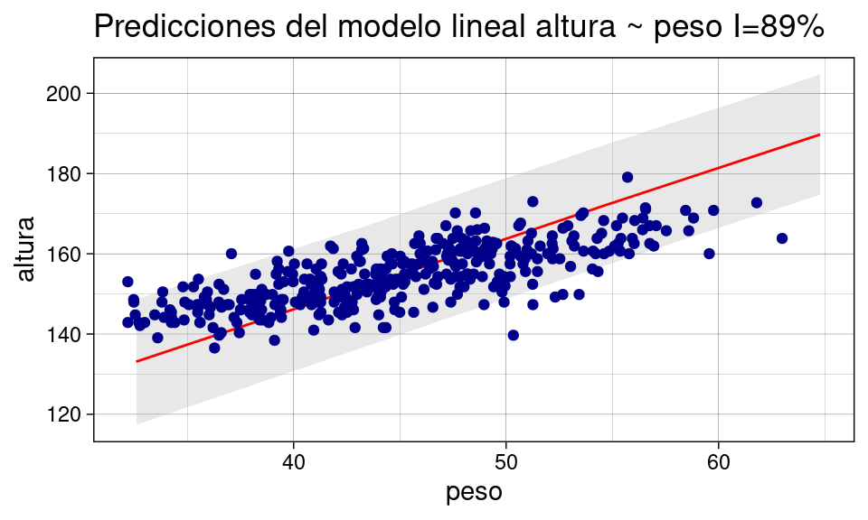

```r
#Graficamos las predicciones de la posterior del modelo para la altura (media y bandas del 89%) incorporando los datos observados
g_1a<-post_predict_1a %>% #usamos las predicciones que obtuvimos con la función posterior_predict()
  ggplot(aes(peso,altura_prom)) + #graficamos peso vs altura_prom
  geom_ribbon(aes(ymin=altura_lim_inf,ymax=altura_lim_sup),fill = "grey70",alpha=.3) + #bandas de predicción
  geom_line(color="red") + #media de predicciones
  geom_jitter(data=howell %>% filter(peso>32), #agregamos los datos de la muestra filtrándolas con peso mayor a 32
              aes(peso,altura),
              height = 0, width = 0.01, colour="darkblue") +
  labs(title = "Predicciones del modelo lineal altura ~ peso I=89%") +
  labs(y = "altura")
g_1a
```

2. Ajusta un modelo lineal para personas menores de 18 años de edad utilizando como predictores la `edad` y el `peso`. Interpreta los coeficientes que resultan del modelo. Si consideras necesario centra los valores de las variables predictoras.

### Respuesta:

Primero filtramos la muestra con las personas menores a 18 años

```r
menores.edad<-datos1 %>% filter(edad < 18) #copiamos la muestra filtrando por los individuos con edades menores a 18 años
menores.edad$genero<-factor(menores.edad$genero) #convertimos la variable a factor
summary(menores.edad) #generamos resumen de las estadísticas
```

```
##      altura            peso             edad        genero
##  Min.   : 53.98   Min.   : 4.252   Min.   : 0.000   0:100
##  1st Qu.: 89.13   1st Qu.:11.708   1st Qu.: 3.000   1: 92
##  Median :111.12   Median :16.981   Median : 7.000
##  Mean   :108.32   Mean   :18.414   Mean   : 7.722
##  3rd Qu.:127.72   3rd Qu.:23.417   3rd Qu.:12.000
##  Max.   :158.12   Max.   :44.736   Max.   :17.000
```

Calculamos un resumen con estadísticas de dispersión, en este caso la mediana de la edad es de sólo 7 años y la muestra se reduce a 192 observaciones: 92 varones y 100 mujeres. La altura promedio de los datos ahora es de sólo 108 centímetros o 1.08 metros.

Posteriormente, centramos las variables alrededor de su media para poder dar una interpretación más sencilla al modelo lineal para predecir la altura:

```r
peso.centrado<-as.data.frame(scale(menores.edad$peso,scale=FALSE)) #centramos peso alrededor de su media
colnames(peso.centrado)<-c("peso.centrado") #lo nombramos peso.centrado
edad.centrada<-as.data.frame(scale(menores.edad$edad,scale=FALSE)) #centramos edad alrededor de su media
colnames(edad.centrada)<-c("edad.centrada") #lo nombramos peso.centrado
menores.edad<-cbind(menores.edad,peso.centrado,edad.centrada) #integramos las variables en menores.edad
head(menores.edad) #imprimimos las primeras observaciones
```

```
##   altura     peso edad genero peso.centrado edad.centrada
## 1 121.92 19.61785 12.0      1      1.203661      4.278125
## 2 105.41 13.94795  8.0      0     -4.466239      0.278125
## 3  86.36 10.48931  6.5      0     -7.924878     -1.221875
## 4 129.54 23.58678 13.0      1      5.172591      5.278125
## 5 109.22 15.98912  7.0      0     -2.425075     -0.721875
## 6 137.16 27.32892 17.0      1      8.914725      9.278125
```

Y generamos el modelo con ambos predictores centrados:

```r
fit_1b <- stan_glm(altura ~ peso.centrado + edad.centrada, data = menores.edad, seed=SEED, refresh = 0) #generamos el modelo lineal bayesiano
print(fit_1b) #imprimimos el objeto con el modelo
```

```
## stan_glm
##  family:       gaussian [identity]
##  formula:      altura ~ peso.centrado + edad.centrada
##  observations: 192
##  predictors:   3
## ------
##               Median MAD_SD
## (Intercept)   108.3    0.5
## peso.centrado   1.4    0.1
## edad.centrada   2.3    0.2
##
## Auxiliary parameter(s):
##       Median MAD_SD
## sigma 6.9    0.4
##
## ------
## * For help interpreting the printed output see ?print.stanreg
## * For info on the priors used see ?prior_summary.stanreg
```

Obtenemos un resumen del modelo:

```r
summary(fit_1b) #generamos resumen de las estadísticas
```

```
##
## Model Info:
##  function:     stan_glm
##  family:       gaussian [identity]
##  formula:      altura ~ peso.centrado + edad.centrada
##  algorithm:    sampling
##  sample:       4000 (posterior sample size)
##  priors:       see help('prior_summary')
##  observations: 192
##  predictors:   3
##
## Estimates:
##                 mean   sd    10%   50%   90%
## (Intercept)   108.3    0.5 107.7 108.3 109.0
## peso.centrado   1.4    0.1   1.3   1.4   1.6
## edad.centrada   2.3    0.2   2.0   2.3   2.6
## sigma           6.9    0.4   6.5   6.9   7.4
##
## Fit Diagnostics:
##            mean   sd    10%   50%   90%
## mean_PPD 108.3    0.7 107.4 108.3 109.2
##
## The mean_ppd is the sample average posterior predictive distribution of the outcome variable (for details see help('summary.stanreg')).
##
## MCMC diagnostics
##               mcse Rhat n_eff
## (Intercept)   0.0  1.0  3145
## peso.centrado 0.0  1.0  1917
## edad.centrada 0.0  1.0  1909
## sigma         0.0  1.0  2671
## mean_PPD      0.0  1.0  3483
## log-posterior 0.0  1.0  1582
##
## For each parameter, mcse is Monte Carlo standard error, n_eff is a crude measure of effective sample size, and Rhat is the potential scale reduction factor on split chains (at convergence Rhat=1).
```

De los resultados anteriores, vemos que el intercepto representa la altura promedio de los menores de 18 años para una persona con un peso y edad alrededor del promedio la cual corresponde a 108 cm o 1.08 metros como vimos al inicio. Por otro lado, el peso y edad centrada tienen un coeficiente positivo en el modelo, lo cual indica para ambos predictores un incremento sobre el valor promedio centrado del peso y la edad contribuyen a un aumento sobre la predicción de la altura. En el caso del peso.centrado, por cada incremento de una unidad, predicción de la altura aumenta 1.4 cm la altura mientras que en la edad centrada por cada incremento de una unidad, la predicción de altura sube 2.3cm adicionales.

3. Para el modelo resultante, haz gráficos que muestren la relación de la variable objetivo con los predictores. De igual forma, incorpora en la visualización la respuesta del modelo lineal junto con intervalos de predicción al 89% y 97%, de tal forma que incorpores la incertidumbre que se ha cuantificado en tu gráfico.

### Respuesta:

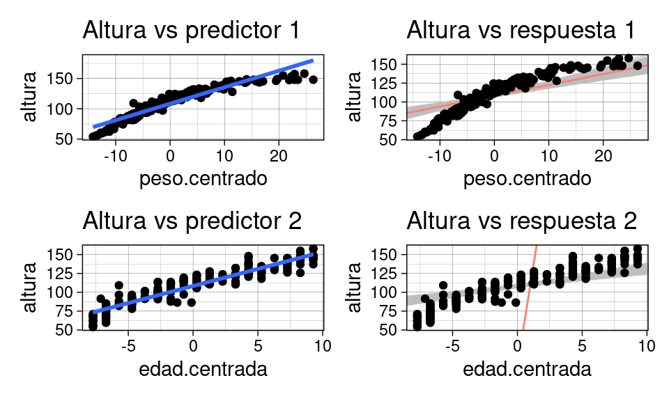

```r
#Gráfico Dispersión altura vs predictor 1: peso.centrado
g_1c_altura_peso.centrado<-menores.edad %>%
  ggplot(aes(x=peso.centrado,y=altura)) +
  geom_point()+
  geom_smooth(method = "lm")+
  labs(title = "Altura vs predictor 1")

#Gráfico Dispersión altura vs predictor 2: edad.centrada
g_1c_altura_edad.centrada<-menores.edad %>%
  ggplot(aes(x=edad.centrada,y=altura)) +
  geom_point()+
  geom_smooth(method = "lm")+
  labs(title = "Altura vs predictor 2")

#Gráfico altura vs predictor 1: peso.centrado
g_1c_altura_pred_peso<-ggplot(data = menores.edad, aes(x = peso.centrado, y = altura))  +
    geom_abline(data = as_tibble(fit_1b) %>% sample_frac(.2),
                aes(slope = peso.centrado, intercept = `(Intercept)`),
                color = 'grey', alpha = .4) +
    geom_abline(slope = coef(fit_1b)[2], intercept = coef(fit_1b)[1], color = 'salmon') +
    geom_point()+
  labs(title = "Altura vs respuesta 1")

#Gráfico altura vs predictor 2: edad.centrada
g_1c_altura_pred_edad<-ggplot(data = menores.edad, aes(x = edad.centrada, y = altura))  +
    geom_abline(data = as_tibble(fit_1b) %>% sample_frac(.2),
                aes(slope = edad.centrada, intercept = `(Intercept)`),
                color = 'grey', alpha = .4) +
    geom_abline(slope = coef(fit_1b)[1], intercept = coef(fit_1b)[2], color = 'salmon') +
    geom_point()+
  labs(title = "Altura vs respuesta 2")

g_1c_altura_peso.centrado+g_1c_altura_pred_peso+g_1c_altura_edad.centrada+g_1c_altura_pred_edad
```

Se aprecia una relación cercana a la lineal con ambos predictores.

Ahora buscamos incorporar un intervalo de confianza de la recta de regresión que condicione en la mediana del coeficiente de la variable que se queda fuera del modelo. Buscamos obtener la distribución posterior del intercepto y edad.centrada ( o intercepto y peso.centrado) dado que peso.centrado toma el valor mediano ( o edad.centrada toma el valor mediano).

```r
cond_edad<-as_tibble(fit_1b)%>% filter(edad.centrada>=(2.33-.01) & edad.centrada<=(2.33+.01))
cond_peso<-as_tibble(fit_1b)%>% filter(peso.centrado>=(1.43-.01) & peso.centrado<=(1.43+.01))

sim<-function(df,var,min,max){
  sim_df<-matrix(nrow=200,ncol=0)
  for(xvar in seq(min,max,.5)){
    hist<-c()
    for(i in seq(1,200)){
      x<-sample_n(df,1)
      val<-x[["(Intercept)"]]+x[[var]]*xvar
      hist<-c(hist,val)

    }
    sim_df<-cbind(sim_df,hist)
  }
  colnames(sim_df)<-seq(min,max,.5)
  return(sim_df)
}

peso<-sim(cond_edad,"peso.centrado",-20,30)
edad<-sim(cond_peso,"edad.centrada",-10,10)
```

```r
peso_range<-seq(-20,30,.5)
peso_sum<-matrix(nrow=0,ncol=3)
for (i in seq(1,ncol(peso))){

  peso_sum<-rbind(peso_sum,c(peso_range[i],quantile(peso[,i],.055)[[1]], quantile(peso[,i],.945)[[1]]))


}

edad_range<-seq(-10,10,.5)
edad_sum<-matrix(nrow=0,ncol=3)
for (i in seq(1,ncol(edad))){

  edad_sum<-rbind(edad_sum,c(edad_range[i],quantile(peso[,i],.055)[[1]], quantile(peso[,i],.945)[[1]]))


}

colnames(edad_sum)<-c("edad.centrada","altura_low","altura_high")
colnames(peso_sum)<-c("peso.centrado","altura_low","altura_high")

edad_sum<-as_tibble(edad_sum)
peso_sum<-as_tibble(peso_sum)
```

```r
edad_sum<-cbind(edad_sum,c(coef(fit_1b)[[1]]+coef(fit_1b)[[3]]*edad_sum[,1]))
peso_sum<-cbind(peso_sum,c(coef(fit_1b)[[1]]+coef(fit_1b)[[2]]*peso_sum[,1]))

colnames(edad_sum)<-c("edad.centrada","altura_low","altura_high","altura_mean")
colnames(peso_sum)<-c("peso.centrado","altura_low","altura_high","altura_mean")

 g_points_edad <-geom_point(data= menores.edad, aes(edad.centrada,altura),alpha=.1)
  g_1a<-as_tibble(edad_sum) %>%
  ggplot(aes(edad.centrada,altura_mean)) + #graficamos peso vs altura_prom
  geom_ribbon(aes(ymin=altura_low,ymax=altura_high),fill = "grey70",alpha=.3)+ #bandas de predicción
  geom_line(color="red") + #media de predicciones
  ggtitle("Altura vs respuesta 1")+
  ylab("altura")

 g_points_peso <-geom_point(data= menores.edad, aes(peso.centrado,altura),alpha=.1)
  g_1a_2<-as_tibble(peso_sum) %>%
  ggplot(aes(peso.centrado,altura_mean)) + #graficamos peso vs altura_prom
  geom_ribbon(aes(ymin=altura_low,ymax=altura_high),fill = "grey70",alpha=.3)+ #bandas de predicción
  geom_line(color="red") + #media de predicciones
  ggtitle("Altura vs respuesta 2")+
  ylab("altura")
```

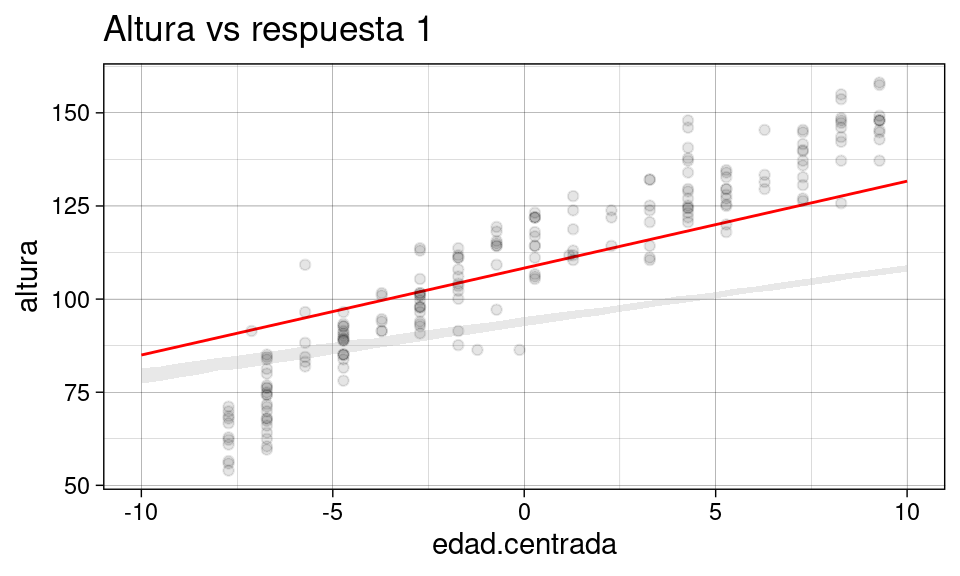

```r
g_1a+g_points_edad
```

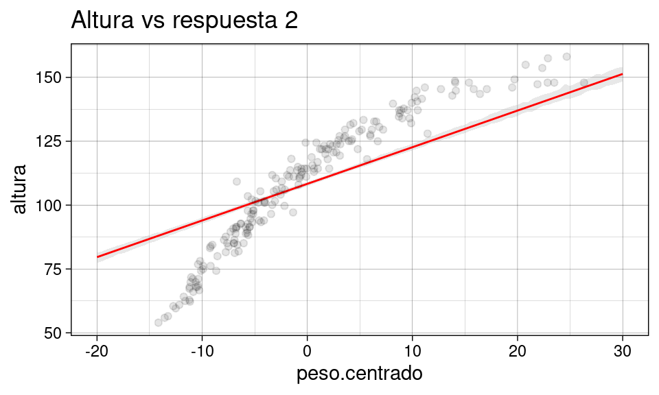

```r
g_1a_2+g_points_peso
```

4. Supongamos que tenemos una amiga que es experta en [alometría](https://es.wikipedia.org/wiki/Alometr%C3%ADa) y les menciona que el peso es suficiente, pero que se debería de incorporar en términos de una escala logarítmica. Ajusta el modelo con todos las observaciones y compara con el modelo del inciso a) y un modelo adicional que sólo incorpora el `peso`. ¿Cuál parece tener mejor capacidad predictiva?

### Respuesta:

Primero creamos la variable log.peso donde calculamos el logaritmo natural aplicado al peso sobre todas las observaciones de nuestra muestra.

```r
howell<-howell %>%
  mutate(log.peso = log(peso)) #creamos la variable log.peso aplicando el logaritmo natural al peso

head(howell) #imprimimos las primeras observaciones
```

```
## # A tibble: 6 x 5
##   altura  peso  edad genero log.peso
##    <dbl> <dbl> <dbl> <fct>     <dbl>
## 1   152.  47.8    63 1          3.87
## 2   140.  36.5    63 0          3.60
## 3   137.  31.9    65 0          3.46
## 4   157.  53.0    41 1          3.97
## 5   145.  41.3    51 0          3.72
## 6   164.  63.0    35 1          4.14
```

Luego ajustamos el modelo:

```r
fit_1d_v1 <- stan_glm(altura ~ log.peso, data = howell, seed=SEED, refresh = 0) #generamos el modelo lineal bayesiano
summary(fit_1d_v1) #mostramos el resumen del modelo
```

```
##
## Model Info:
##  function:     stan_glm
##  family:       gaussian [identity]
##  formula:      altura ~ log.peso
##  algorithm:    sampling
##  sample:       4000 (posterior sample size)
##  priors:       see help('prior_summary')
##  observations: 544
##  predictors:   2
##
## Estimates:
##               mean   sd    10%   50%   90%
## (Intercept) -23.9    1.3 -25.6 -23.9 -22.1
## log.peso     47.1    0.4  46.6  47.1  47.6
## sigma         5.2    0.2   5.0   5.1   5.4
##
## Fit Diagnostics:
##            mean   sd    10%   50%   90%
## mean_PPD 138.3    0.3 137.9 138.3 138.7
##
## The mean_ppd is the sample average posterior predictive distribution of the outcome variable (for details see help('summary.stanreg')).
##
## MCMC diagnostics
##               mcse Rhat n_eff
## (Intercept)   0.0  1.0  3990
## log.peso      0.0  1.0  4009
## sigma         0.0  1.0  3300
## mean_PPD      0.0  1.0  3708
## log-posterior 0.0  1.0  1902
##
## For each parameter, mcse is Monte Carlo standard error, n_eff is a crude measure of effective sample size, and Rhat is the potential scale reduction factor on split chains (at convergence Rhat=1).
```

Después de calcular este modelo, observamos que el coeficiente del intercepto es negativo. Por ello, se decidió crear una nueva variable log.peso.centrado centrando log.peso alrededor de su media para generar una interpretación del modelo.

```r
howell<-howell %>%
  mutate(log.peso.centrado = log.peso-mean(log.peso)) #creamos la variable log.peso.centrado centrando por la media

head(howell) #imprimimos las primeras observaciones
```

```
## # A tibble: 6 x 6
##   altura  peso  edad genero log.peso log.peso.centrado
##    <dbl> <dbl> <dbl> <fct>     <dbl>             <dbl>
## 1   152.  47.8    63 1          3.87            0.425
## 2   140.  36.5    63 0          3.60            0.155
## 3   137.  31.9    65 0          3.46            0.0192
## 4   157.  53.0    41 1          3.97            0.529
## 5   145.  41.3    51 0          3.72            0.278
## 6   164.  63.0    35 1          4.14            0.701
```

Y volvemos a ajustar un modelo:

```r
fit_1d <- stan_glm(altura ~ log.peso.centrado, data = howell, seed=SEED, refresh = 0) #generamos el modelo lineal bayesiano
summary(fit_1d) #mostramos el resumen del modelo
```

```
##
## Model Info:
##  function:     stan_glm
##  family:       gaussian [identity]
##  formula:      altura ~ log.peso.centrado
##  algorithm:    sampling
##  sample:       4000 (posterior sample size)
##  priors:       see help('prior_summary')
##  observations: 544
##  predictors:   2
##
## Estimates:
##                     mean   sd    10%   50%   90%
## (Intercept)       138.3    0.2 138.0 138.3 138.5
## log.peso.centrado  47.1    0.4  46.6  47.1  47.6
## sigma               5.2    0.2   5.0   5.1   5.4
##
## Fit Diagnostics:
##            mean   sd    10%   50%   90%
## mean_PPD 138.3    0.3 137.9 138.3 138.7
##
## The mean_ppd is the sample average posterior predictive distribution of the outcome variable (for details see help('summary.stanreg')).
##
## MCMC diagnostics
##                   mcse Rhat n_eff
## (Intercept)       0.0  1.0  3257
## log.peso.centrado 0.0  1.0  4009
## sigma             0.0  1.0  3300
## mean_PPD          0.0  1.0  3708
## log-posterior     0.0  1.0  1902
##
## For each parameter, mcse is Monte Carlo standard error, n_eff is a crude measure of effective sample size, and Rhat is the potential scale reduction factor on split chains (at convergence Rhat=1).
```

Ya que el signo del coeficiente es positivo, nos quedaremos con esta versión para compararla con el del inciso a). Es decir, utilizamos los criterios de información de los modelos para medir la capacidad predictiva del modelo del inciso a) y d) por medio de la devianza y log-densidad haciendo uso de validación cruzada con los métodos de waic y loo.

Primero calculamos la devianza de ambos modelos con waic:

```r
waic_1a<-waic(fit_1a) #calcula: elpd_waic que corresponde a la log-densidad; p_waic: el número efectivo de parámetros; waic: la devianza del modelo así como suss errores estándar variando sobre todas las observaciones
waic_1d<-waic(fit_1d) #calcula: elpd_waic que corresponde a la log-densidad; p_waic: el número efectivo de parámetros; waic: la devianza del modelo así como suss errores estándar variando sobre todas las observaciones

comparativo_waic_1d<-cbind(waic_1a,waic_1d) #combina resultados para comparar
comparativo_waic_1d
```

```
##              waic_1a      waic_1d
## estimates    Numeric,6    Numeric,6
## pointwise    Numeric,1632 Numeric,1632
## elpd_waic    -1991.131    -1665.009
## p_waic       3.775202     3.184316
## waic         3982.261     3330.018
## se_elpd_waic 17.14891     18.31412
## se_p_waic    0.4124174    0.4016857
## se_waic      34.29782     36.62825
```

Y los resultados arrojan que el modelo es el d) que incorpora el peso en escala logarítmica como predictor tiene un mejor desempeño ya que es el de menor devianza 3,330 en contraste con el del inciso a) 3,982.

Luego generamos un comparativo en términos de la log-densidad predictiva con el método loo_compare().

```r
comparativo_diff_waic_1d<-loo_compare(waic_1a,waic_1d) #calcula comparativo de diferencia en términos de la log-densidad predictiva y un error estándar sobre esta diferencia (se_diff). Ordenando los modelos del mejor al peor
comparativo_diff_waic_1d #imprime comparativo
```

```
##        elpd_diff se_diff
## fit_1d    0.0       0.0
## fit_1a -326.1      19.5
```

Estos resultados también identifican al modelo del inciso d como el mejor pues tiene una mayor log-densidad predictiva. Además se aprecia una diferencia relativamente grande en la log-densidad predictiva y el error estándar del modelo d) con respecto al del inciso a).

Por último comparamos los modelos con validación cruzada mediante la función loo():

```r
loo_1a<-loo(fit_1a) #calcula: elpd_loo que corresponde a la log-densidad; p_loo: el número efectivo de parámetros; looic: la devianza del modelo así como suss errores estándar (SE) variando sobre todas las observaciones con validación cruzada
loo_1a #imprime resultados
```

```
##
## Computed from 4000 by 544 log-likelihood matrix
##
##          Estimate   SE
## elpd_loo  -1991.1 17.1
## p_loo         3.8  0.4
## looic      3982.3 34.3
## ------
## Monte Carlo SE of elpd_loo is 0.0.
##
## All Pareto k estimates are good (k < 0.5).
## See help('pareto-k-diagnostic') for details.
```

```r
loo_1d<-loo(fit_1d) #calcula: elpd_loo que corresponde a la log-densidad; p_loo: el número efectivo de parámetros; looic: la devianza del modelo así como suss errores estándar (SE) variando sobre todas las observaciones con validación cruzada
loo_1d #imprime resultados
```

```
##
## Computed from 4000 by 544 log-likelihood matrix
##
##          Estimate   SE
## elpd_loo  -1665.0 18.3
## p_loo         3.2  0.4
## looic      3330.0 36.6
## ------
## Monte Carlo SE of elpd_loo is 0.0.
##
## All Pareto k estimates are good (k < 0.5).
## See help('pareto-k-diagnostic') for details.
```

En ambos casos, el diagnóstico que loo arroja es que ambos modelos son buenos y además notamos que las estadísticas coinciden con las obtenidas con el método waic. Por lo que la conclusión no cambia, el mejor modelo también se determina que el modelo del inciso d) es el mejor bajo esta comparación.

```r
comparativo_diff_loo_1d<-loo_compare(loo_1a,loo_1d) #calcula comparativo de diferencia en términos de la log-densidad predictiva y un error estándar sobre esta diferencia (se_diff). Ordenando los modelos del mejor al peor
comparativo_diff_loo_1d #imprime comparativo
```

```
##        elpd_diff se_diff
## fit_1d    0.0       0.0
## fit_1a -326.1      19.5
```

5. ¿Cómo interpretas los coeficientes del mejor modelo del inciso `d`?

### Respuesta:

Como ya mencionamos, el mejor modelo para la predicción de la variable altura fue el d: altura ~ log.peso.centrado, donde utilizamos la variable log(peso) que fue centrada alrededor de su media. Primero mostramos los coeficientes de este modelo:

```r
print(fit_1d) #imprimimos el objeto con el modelo
```

```
## stan_glm
##  family:       gaussian [identity]
##  formula:      altura ~ log.peso.centrado
##  observations: 544
##  predictors:   2
## ------
##                   Median MAD_SD
## (Intercept)       138.3    0.2
## log.peso.centrado  47.1    0.4
##
## Auxiliary parameter(s):
##       Median MAD_SD
## sigma 5.1    0.2
##
## ------
## * For help interpreting the printed output see ?print.stanreg
## * For info on the priors used see ?prior_summary.stanreg
```

De lo anterior se interpreta al intercepto de 138.3 como la estimación para la altura promedio en centímetros de un individuo promedio con un log.peso.centrado promedio (log-kg). El valor del coeficiente $\beta_1$ para la variable log.peso.centrado de 47.1 significa que un incremento de una unidad en la variable log.peso.centrado aumenta 47.1 cm la predicción sobre la altura del individuo.

6. Ahora estudiaremos el efecto de la distribución previa. Para esto consideraremos. La variable de `edad` centrada y probaremos distintos polinomios como predictores. Consideraremos potencias desde 0 hasta términos de grado 6. Ajusta esta colección de posibles modelos.

### Respuesta:

Primero calculamos la variable edad.centrada centrando la variable edad alrededor de su media:

```r
howell.centrado<-datos1 %>%
  mutate(edad.centrada = edad-mean(edad)) #creamos la variable edad.centrada centrando la variable edad por su media
howell.centrado$genero<-factor(howell$genero) #convertimos la variable a factor
head(howell.centrado) #imprimimos las primeras observaciones
```

```
## # A tibble: 6 x 5
##   altura  peso  edad genero edad.centrada
##    <dbl> <dbl> <dbl> <fct>          <dbl>
## 1   152.  47.8    63 1              33.7
## 2   140.  36.5    63 0              33.7
## 3   137.  31.9    65 0              35.7
## 4   157.  53.0    41 1              11.7
## 5   145.  41.3    51 0              21.7
## 6   164.  63.0    35 1               5.66
```

Luego ajustamos 7 modelos para la altura usando como predictores a la edad.centrada en forma de polinomios desde el grado 0 a 6.

```r
#generamos los modelos lineales bayesianos para la altura incorporando como predictor un polinomio grado cero hasta 6 con la edad.centrada
fit_1f_g0 <- stan_glm(altura ~ 1, data = howell.centrado, seed=SEED, refresh = 0)
fit_1f_g1 <- stan_glm(altura ~ poly(edad.centrada,1,raw=TRUE), data = howell.centrado, seed=SEED, refresh = 0)
fit_1f_g2 <- stan_glm(altura ~ poly(edad.centrada,2,raw=TRUE), data = howell.centrado, seed=SEED, refresh = 0)
fit_1f_g3 <- stan_glm(altura ~ poly(edad.centrada,3,raw=TRUE), data = howell.centrado, seed=SEED, refresh = 0)
fit_1f_g4 <- stan_glm(altura ~ poly(edad.centrada,4,raw=TRUE), data = howell.centrado, seed=SEED, refresh = 0)
fit_1f_g5 <- stan_glm(altura ~ poly(edad.centrada,5,raw=TRUE), data = howell.centrado, seed=SEED, refresh = 0)
fit_1f_g6 <- stan_glm(altura ~ poly(edad.centrada,6,raw=TRUE), data = howell.centrado, seed=SEED, refresh = 0)
```

Y a continuación mostramos el resumen de cada modelo:

```r
summary(fit_1f_g0) #mostramos el resumen del modelo
```

```
##
## Model Info:
##  function:     stan_glm
##  family:       gaussian [identity]
##  formula:      altura ~ 1
##  algorithm:    sampling
##  sample:       4000 (posterior sample size)
##  priors:       see help('prior_summary')
##  observations: 544
##  predictors:   1
##
## Estimates:
##               mean   sd    10%   50%   90%
## (Intercept) 138.3    1.2 136.8 138.3 139.8
## sigma        27.6    0.8  26.6  27.6  28.7
##
## Fit Diagnostics:
##            mean   sd    10%   50%   90%
## mean_PPD 138.3    1.7 136.2 138.3 140.5
##
## The mean_ppd is the sample average posterior predictive distribution of the outcome variable (for details see help('summary.stanreg')).
##
## MCMC diagnostics
##               mcse Rhat n_eff
## (Intercept)   0.0  1.0  2773
## sigma         0.0  1.0  2608
## mean_PPD      0.0  1.0  3293
## log-posterior 0.0  1.0  1574
##
## For each parameter, mcse is Monte Carlo standard error, n_eff is a crude measure of effective sample size, and Rhat is the potential scale reduction factor on split chains (at convergence Rhat=1).
```

```r
summary(fit_1f_g1) #mostramos el resumen del modelo
```

```
##
## Model Info:
##  function:     stan_glm
##  family:       gaussian [identity]
##  formula:      altura ~ poly(edad.centrada, 1, raw = TRUE)
##  algorithm:    sampling
##  sample:       4000 (posterior sample size)
##  priors:       see help('prior_summary')
##  observations: 544
##  predictors:   2
##
## Estimates:
##                                      mean   sd    10%   50%   90%
## (Intercept)                        138.3    0.8 137.2 138.3 139.4
## poly(edad.centrada, 1, raw = TRUE)   0.9    0.0   0.9   0.9   1.0
## sigma                               20.2    0.6  19.4  20.2  21.0
##
## Fit Diagnostics:
##            mean   sd    10%   50%   90%
## mean_PPD 138.3    1.2 136.7 138.3 139.9
##
## The mean_ppd is the sample average posterior predictive distribution of the outcome variable (for details see help('summary.stanreg')).
##
## MCMC diagnostics
##                                    mcse Rhat n_eff
## (Intercept)                        0.0  1.0  4042
## poly(edad.centrada, 1, raw = TRUE) 0.0  1.0  3778
## sigma                              0.0  1.0  3626
## mean_PPD                           0.0  1.0  3731
## log-posterior                      0.0  1.0  1934
##
## For each parameter, mcse is Monte Carlo standard error, n_eff is a crude measure of effective sample size, and Rhat is the potential scale reduction factor on split chains (at convergence Rhat=1).
```

```r
summary(fit_1f_g2) #mostramos el resumen del modelo
```

```
##
## Model Info:
##  function:     stan_glm
##  family:       gaussian [identity]
##  formula:      altura ~ poly(edad.centrada, 2, raw = TRUE)
##  algorithm:    sampling
##  sample:       4000 (posterior sample size)
##  priors:       see help('prior_summary')
##  observations: 544
##  predictors:   3
##
## Estimates:
##                                       mean   sd    10%   50%   90%
## (Intercept)                         152.7    0.7 151.8 152.7 153.6
## poly(edad.centrada, 2, raw = TRUE)1   1.3    0.0   1.2   1.3   1.3
## poly(edad.centrada, 2, raw = TRUE)2   0.0    0.0   0.0   0.0   0.0
## sigma                                12.4    0.4  11.9  12.4  12.9
##
## Fit Diagnostics:
##            mean   sd    10%   50%   90%
## mean_PPD 138.3    0.7 137.3 138.3 139.2
##
## The mean_ppd is the sample average posterior predictive distribution of the outcome variable (for details see help('summary.stanreg')).
##
## MCMC diagnostics
##                                     mcse Rhat n_eff
## (Intercept)                         0.0  1.0  4226
## poly(edad.centrada, 2, raw = TRUE)1 0.0  1.0  3880
## poly(edad.centrada, 2, raw = TRUE)2 0.0  1.0  4138
## sigma                               0.0  1.0  4143
## mean_PPD                            0.0  1.0  4216
## log-posterior                       0.0  1.0  1947
##
## For each parameter, mcse is Monte Carlo standard error, n_eff is a crude measure of effective sample size, and Rhat is the potential scale reduction factor on split chains (at convergence Rhat=1).
```

```r
summary(fit_1f_g3) #mostramos el resumen del modelo
```

```
##
## Model Info:
##  function:     stan_glm
##  family:       gaussian [identity]
##  formula:      altura ~ poly(edad.centrada, 3, raw = TRUE)
##  algorithm:    sampling
##  sample:       4000 (posterior sample size)
##  priors:       see help('prior_summary')
##  observations: 544
##  predictors:   4
##
## Estimates:
##                                       mean   sd    10%   50%   90%
## (Intercept)                         158.5    0.5 157.8 158.5 159.2
## poly(edad.centrada, 3, raw = TRUE)1   0.6    0.0   0.5   0.6   0.6
## poly(edad.centrada, 3, raw = TRUE)2  -0.1    0.0  -0.1  -0.1  -0.1
## poly(edad.centrada, 3, raw = TRUE)3   0.0    0.0   0.0   0.0   0.0
## sigma                                 8.5    0.3   8.2   8.5   8.9
##
## Fit Diagnostics:
##            mean   sd    10%   50%   90%
## mean_PPD 138.3    0.5 137.6 138.3 138.9
##
## The mean_ppd is the sample average posterior predictive distribution of the outcome variable (for details see help('summary.stanreg')).
##
## MCMC diagnostics
##                                     mcse Rhat n_eff
## (Intercept)                         0.0  1.0  2957
## poly(edad.centrada, 3, raw = TRUE)1 0.0  1.0  2317
## poly(edad.centrada, 3, raw = TRUE)2 0.0  1.0  2347
## poly(edad.centrada, 3, raw = TRUE)3 0.0  1.0  2027
## sigma                               0.0  1.0  2993
## mean_PPD                            0.0  1.0  3488
## log-posterior                       0.0  1.0  1634
##
## For each parameter, mcse is Monte Carlo standard error, n_eff is a crude measure of effective sample size, and Rhat is the potential scale reduction factor on split chains (at convergence Rhat=1).
```

```r
summary(fit_1f_g4) #mostramos el resumen del modelo
```

```
##
## Model Info:
##  function:     stan_glm
##  family:       gaussian [identity]
##  formula:      altura ~ poly(edad.centrada, 4, raw = TRUE)
##  algorithm:    sampling
##  sample:       4000 (posterior sample size)
##  priors:       see help('prior_summary')
##  observations: 544
##  predictors:   5
##
## Estimates:
##                                       mean   sd    10%   50%   90%
## (Intercept)                         157.0    0.5 156.3 157.0 157.7
## poly(edad.centrada, 4, raw = TRUE)1   0.3    0.0   0.2   0.3   0.3
## poly(edad.centrada, 4, raw = TRUE)2   0.0    0.0   0.0   0.0   0.0
## poly(edad.centrada, 4, raw = TRUE)3   0.0    0.0   0.0   0.0   0.0
## poly(edad.centrada, 4, raw = TRUE)4   0.0    0.0   0.0   0.0   0.0
## sigma                                 7.9    0.2   7.6   7.9   8.2
##
## Fit Diagnostics:
##            mean   sd    10%   50%   90%
## mean_PPD 138.3    0.5 137.7 138.3 138.9
##
## The mean_ppd is the sample average posterior predictive distribution of the outcome variable (for details see help('summary.stanreg')).
##
## MCMC diagnostics
##                                     mcse Rhat n_eff
## (Intercept)                         0.0  1.0  3055
## poly(edad.centrada, 4, raw = TRUE)1 0.0  1.0  1580
## poly(edad.centrada, 4, raw = TRUE)2 0.0  1.0  1853
## poly(edad.centrada, 4, raw = TRUE)3 0.0  1.0  1379
## poly(edad.centrada, 4, raw = TRUE)4 0.0  1.0  1305
## sigma                               0.0  1.0  2888
## mean_PPD                            0.0  1.0  3290
## log-posterior                       0.0  1.0  1426
##
## For each parameter, mcse is Monte Carlo standard error, n_eff is a crude measure of effective sample size, and Rhat is the potential scale reduction factor on split chains (at convergence Rhat=1).
```

```r
summary(fit_1f_g5) #mostramos el resumen del modelo
```

```
##
## Model Info:
##  function:     stan_glm
##  family:       gaussian [identity]
##  formula:      altura ~ poly(edad.centrada, 5, raw = TRUE)
##  algorithm:    sampling
##  sample:       4000 (posterior sample size)
##  priors:       see help('prior_summary')
##  observations: 544
##  predictors:   6
##
## Estimates:
##                                       mean   sd    10%   50%   90%
## (Intercept)                         156.8    0.6 156.0 156.8 157.6
## poly(edad.centrada, 5, raw = TRUE)1   0.3    0.0   0.2   0.3   0.3
## poly(edad.centrada, 5, raw = TRUE)2   0.0    0.0   0.0   0.0   0.0
## poly(edad.centrada, 5, raw = TRUE)3   0.0    0.0   0.0   0.0   0.0
## poly(edad.centrada, 5, raw = TRUE)4   0.0    0.0   0.0   0.0   0.0
## poly(edad.centrada, 5, raw = TRUE)5   0.0    0.0   0.0   0.0   0.0
## sigma                                 7.9    0.2   7.6   7.9   8.2
##
## Fit Diagnostics:
##            mean   sd    10%   50%   90%
## mean_PPD 138.3    0.5 137.6 138.3 138.9
##
## The mean_ppd is the sample average posterior predictive distribution of the outcome variable (for details see help('summary.stanreg')).
##
## MCMC diagnostics
##                                     mcse Rhat n_eff
## (Intercept)                         0.0  1.0  2390
## poly(edad.centrada, 5, raw = TRUE)1 0.0  1.0  2253
## poly(edad.centrada, 5, raw = TRUE)2 0.0  1.0  1609
## poly(edad.centrada, 5, raw = TRUE)3 0.0  1.0  1935
## poly(edad.centrada, 5, raw = TRUE)4 0.0  1.0  1614
## poly(edad.centrada, 5, raw = TRUE)5 0.0  1.0  1560
## sigma                               0.0  1.0  2512
## mean_PPD                            0.0  1.0  3476
## log-posterior                       0.1  1.0  1409
##
## For each parameter, mcse is Monte Carlo standard error, n_eff is a crude measure of effective sample size, and Rhat is the potential scale reduction factor on split chains (at convergence Rhat=1).
```

```r
summary(fit_1f_g6) #mostramos el resumen del modelo
```

```
##
## Model Info:
##  function:     stan_glm
##  family:       gaussian [identity]
##  formula:      altura ~ poly(edad.centrada, 6, raw = TRUE)
##  algorithm:    sampling
##  sample:       4000 (posterior sample size)
##  priors:       see help('prior_summary')
##  observations: 544
##  predictors:   7
##
## Estimates:
##                                       mean   sd    10%   50%   90%
## (Intercept)                         156.9    0.6 156.1 156.9 157.7
## poly(edad.centrada, 6, raw = TRUE)1   0.2    0.1   0.1   0.2   0.3
## poly(edad.centrada, 6, raw = TRUE)2   0.0    0.0   0.0   0.0   0.0
## poly(edad.centrada, 6, raw = TRUE)3   0.0    0.0   0.0   0.0   0.0
## poly(edad.centrada, 6, raw = TRUE)4   0.0    0.0   0.0   0.0   0.0
## poly(edad.centrada, 6, raw = TRUE)5   0.0    0.0   0.0   0.0   0.0
## poly(edad.centrada, 6, raw = TRUE)6   0.0    0.0   0.0   0.0   0.0
## sigma                                 7.9    0.2   7.6   7.9   8.2
##
## Fit Diagnostics:
##            mean   sd    10%   50%   90%
## mean_PPD 138.3    0.5 137.7 138.3 138.9
##
## The mean_ppd is the sample average posterior predictive distribution of the outcome variable (for details see help('summary.stanreg')).
##
## MCMC diagnostics
##                                     mcse Rhat n_eff
## (Intercept)                         0.0  1.0  2453
## poly(edad.centrada, 6, raw = TRUE)1 0.0  1.0  1380
## poly(edad.centrada, 6, raw = TRUE)2 0.0  1.0  1915
## poly(edad.centrada, 6, raw = TRUE)3 0.0  1.0  1121
## poly(edad.centrada, 6, raw = TRUE)4 0.0  1.0  1917
## poly(edad.centrada, 6, raw = TRUE)5 0.0  1.0  1135
## poly(edad.centrada, 6, raw = TRUE)6 0.0  1.0  1180
## sigma                               0.0  1.0  3066
## mean_PPD                            0.0  1.0  3411
## log-posterior                       0.1  1.0  1516
##
## For each parameter, mcse is Monte Carlo standard error, n_eff is a crude measure of effective sample size, and Rhat is the potential scale reduction factor on split chains (at convergence Rhat=1).
```

7. Para cada modelo en el inciso de arriba, genera gráficos que muestren las predicciones junto con las bandas de predicción.

### Respuesta:

Creamos las predicciones y gráficos con bandas de predicción considerando un intervalo del 89% a partir de funciones

```r
#función para calcular las predicciones de la posterior de los modelos para la altura (media y bandas del 89%)
df4plot<-function(model){
  edad.centrada<-tibble(seq(-40,70))
  colnames(edad.centrada)<-"edad.centrada"
  df<-as_tibble(posterior_predict(model, newdata=edad.centrada,seed=SEED)) %>%  #calculamos las predicciones con la posterior
  #cada fila es una simulación bajo una muestra distinta
  mutate(sample_id = 1:4000) %>% #creamos ID para cada
  pivot_longer(cols = 1:nrow(edad.centrada)) %>%
  mutate(name = fct_inorder(name)) %>%
  group_by(name) %>% #name es la predicción de cada individuo (1-5)
  summarise(altura_mean=mean(value), #calcula media
            altura_median=median(value), #calcula mediana
            altura_low=quantile(value,.055), #intervalos del 89% de probabilidad
            altura_hi=quantile(value,.945))
df$edad.centrada<-as_vector(edad.centrada)
return(df)
}

#función que genera gráfico de predicciones para un modelo
plots<-function(df,points,title){
  g_points <-geom_point(data= points, aes(edad.centrada,altura),alpha=.1)
  g_1a<-df %>%
    ggplot(aes(edad.centrada,altura_mean)) + #graficamos peso vs altura_prom
    geom_ribbon(aes(ymin=altura_low,ymax=altura_hi),fill = "grey70",alpha=.3)+ #bandas de predicción
    geom_line(color="red") + #media de predicciones
    ggtitle(title)+
    ylab("altura")

  g_1a+g_points
}
```

```r
#guardamos predicciones
post_predict_1f_g0 <- df4plot(fit_1f_g0)
post_predict_1f_g1 <- df4plot(fit_1f_g1)
post_predict_1f_g2 <- df4plot(fit_1f_g2)
post_predict_1f_g3 <- df4plot(fit_1f_g3)
post_predict_1f_g4 <- df4plot(fit_1f_g4)
post_predict_1f_g5 <- df4plot(fit_1f_g5)
post_predict_1f_g6 <- df4plot(fit_1f_g6)

#guardamos gráficos
g_g0<-plots(post_predict_1f_g0,howell.centrado,"Predicciones con polinomio grado 0 (I. 89%)")
g_g1<-plots(post_predict_1f_g1,howell.centrado,"Predicciones con polinomio grado 1 (I. 89%)")
g_g2<-plots(post_predict_1f_g2,howell.centrado,"Predicciones con polinomio grado 2 (I. 89%)")
g_g3<-plots(post_predict_1f_g3,howell.centrado,"Predicciones con polinomio grado 3 (I. 89%)")
g_g4<-plots(post_predict_1f_g4,howell.centrado,"Predicciones con polinomio grado 4 (I. 89%)")
g_g5<-plots(post_predict_1f_g5,howell.centrado,"Predicciones con polinomio grado 5 (I. 89%)")
g_g6<-plots(post_predict_1f_g6,howell.centrado,"Predicciones con polinomio grado 6 (I. 89%)")
```

Y presentamos los gráficos de cada modelo:

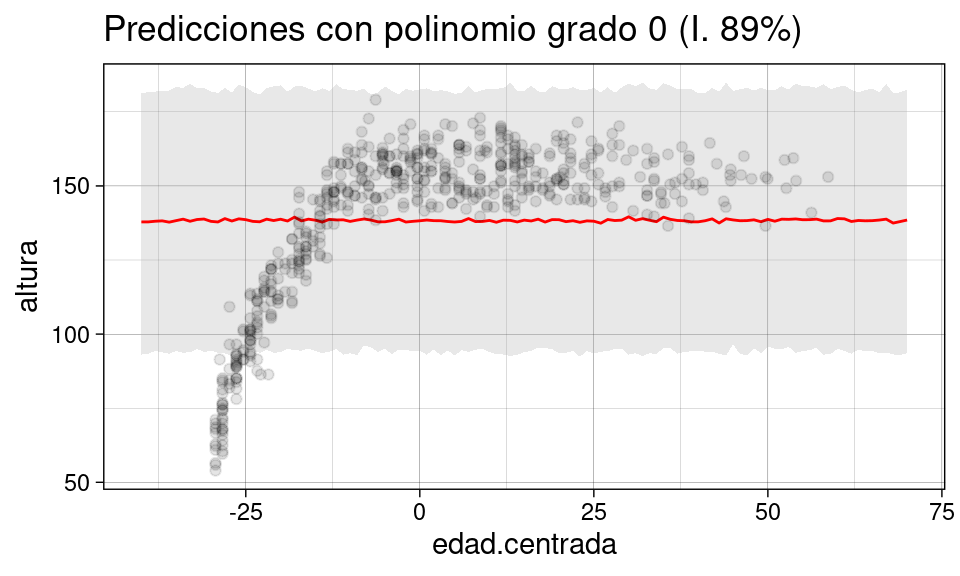

```r
g_g0 #muestra gráfica
```

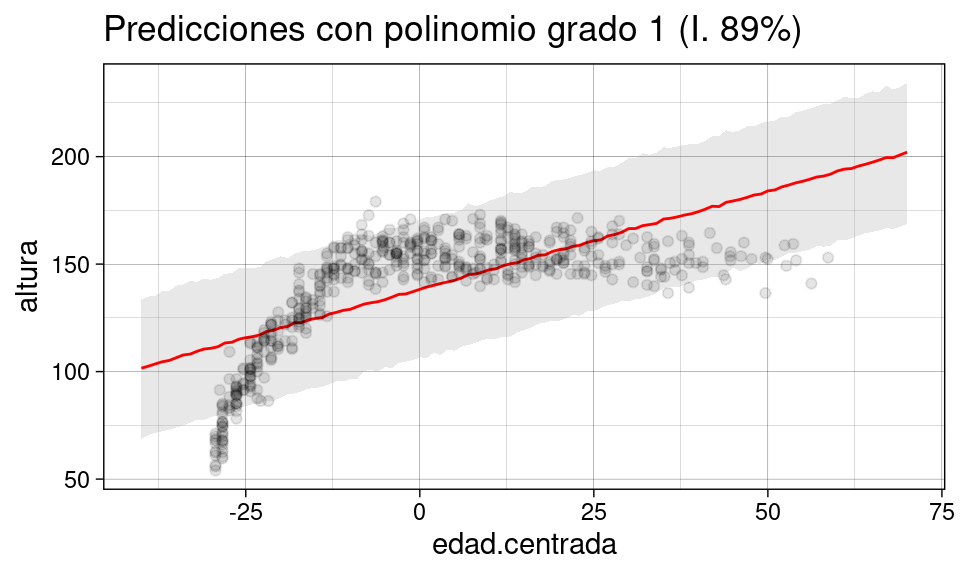

```r
g_g1 #muestra gráfica
```

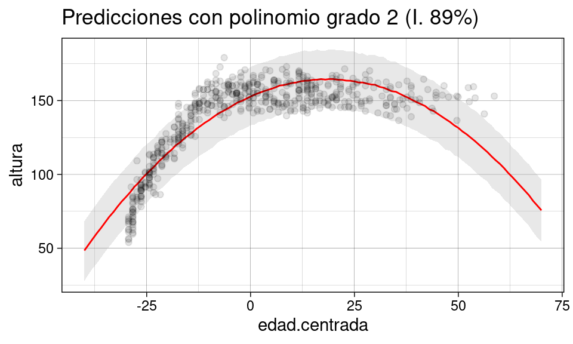

```r
g_g2 #muestra gráfica
```

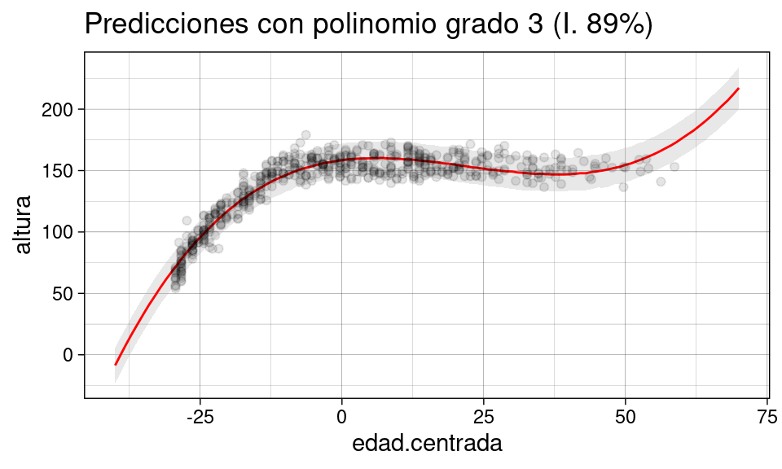

```r
g_g3 #muestra gráfica
```

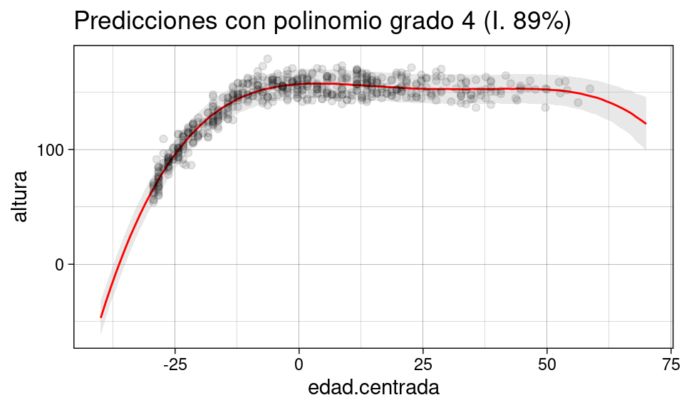

```r
g_g4 #muestra gráfica
```

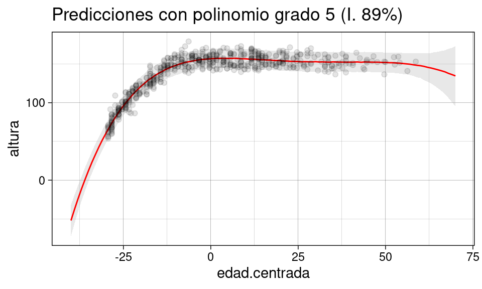

```r
g_g5 #muestra gráfica
```

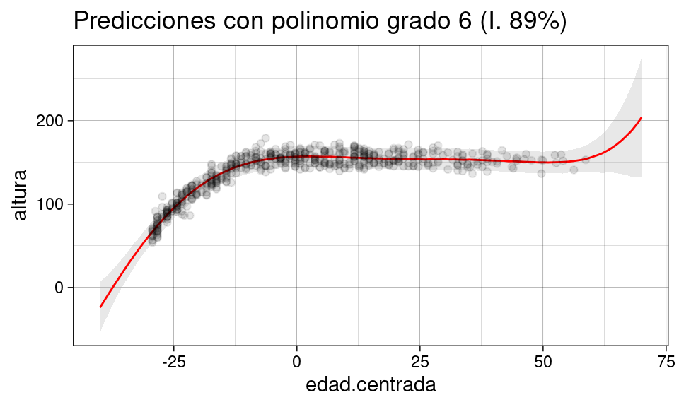

```r
g_g6 #muestra gráfica
```

8. Realiza una evaluación de los modelos resultantes con el criterio de información que consideres más apropiado.

### Respuesta:

Para la evaluación de modelos nos basaremos en el criterio de información de loo ya que como vimos en el inciso d, el método loo() nos genera un diagnóstico del modelo y utiliza validación cruzada para evaluar su capacidad predictiva. A su vez, para una conclusión tomaremos en cuenta el principio de parsimonia en el que se prefiere el modelo más sencillo posible.

A continuación presentamos los diagnósticos:

```r
loo_1g_g0<-loo(fit_1f_g0) #calcula: elpd_loo que corresponde a la log-densidad; p_loo: el número efectivo de parámetros; looic: la devianza del modelo así como suss errores estándar (SE) variando sobre todas las observaciones con validación cruzada
loo_1g_g0  #imprime resultados
```

```
##
## Computed from 4000 by 544 log-likelihood matrix
##
##          Estimate   SE
## elpd_loo  -2578.5 18.9
## p_loo         2.3  0.2
## looic      5157.0 37.8
## ------
## Monte Carlo SE of elpd_loo is 0.0.
##
## All Pareto k estimates are good (k < 0.5).
## See help('pareto-k-diagnostic') for details.
```

```r
loo_1g_g1<-loo(fit_1f_g1) #calcula: elpd_loo que corresponde a la log-densidad; p_loo: el número efectivo de parámetros; looic: la devianza del modelo así como suss errores estándar (SE) variando sobre todas las observaciones con validación cruzada
loo_1g_g1  #imprime resultados
```

```
##
## Computed from 4000 by 544 log-likelihood matrix
##
##          Estimate   SE
## elpd_loo  -2408.2 15.4
## p_loo         3.4  0.3
## looic      4816.4 30.9
## ------
## Monte Carlo SE of elpd_loo is 0.0.
##
## All Pareto k estimates are good (k < 0.5).
## See help('pareto-k-diagnostic') for details.
```

```r
loo_1g_g2<-loo(fit_1f_g2) #calcula: elpd_loo que corresponde a la log-densidad; p_loo: el número efectivo de parámetros; looic: la devianza del modelo así como suss errores estándar (SE) variando sobre todas las observaciones con validación cruzada
loo_1g_g2  #imprime resultados
```

```
##
## Computed from 4000 by 544 log-likelihood matrix
##
##          Estimate   SE
## elpd_loo  -2143.7 16.4
## p_loo         5.8  1.1
## looic      4287.3 32.9
## ------
## Monte Carlo SE of elpd_loo is 0.0.
##
## All Pareto k estimates are good (k < 0.5).
## See help('pareto-k-diagnostic') for details.
```

```r
loo_1g_g3<-loo(fit_1f_g3) #calcula: elpd_loo que corresponde a la log-densidad; p_loo: el número efectivo de parámetros; looic: la devianza del modelo así como suss errores estándar (SE) variando sobre todas las observaciones con validación cruzada
loo_1g_g3  #imprime resultados
```

```
##
## Computed from 4000 by 544 log-likelihood matrix
##
##          Estimate   SE
## elpd_loo  -1939.5 16.4
## p_loo         6.3  1.3
## looic      3879.0 32.8
## ------
## Monte Carlo SE of elpd_loo is 0.1.
##
## All Pareto k estimates are good (k < 0.5).
## See help('pareto-k-diagnostic') for details.
```

```r
loo_1g_g4<-loo(fit_1f_g4) #calcula: elpd_loo que corresponde a la log-densidad; p_loo: el número efectivo de parámetros; looic: la devianza del modelo así como suss errores estándar (SE) variando sobre todas las observaciones con validación cruzada
loo_1g_g4  #imprime resultados
```

```
##
## Computed from 4000 by 544 log-likelihood matrix
##
##          Estimate   SE
## elpd_loo  -1899.2 16.6
## p_loo         5.8  0.6
## looic      3798.3 33.1
## ------
## Monte Carlo SE of elpd_loo is 0.1.
##
## All Pareto k estimates are good (k < 0.5).
## See help('pareto-k-diagnostic') for details.
```

```r
loo_1g_g5<-loo(fit_1f_g5) #calcula: elpd_loo que corresponde a la log-densidad; p_loo: el número efectivo de parámetros; looic: la devianza del modelo así como suss errores estándar (SE) variando sobre todas las observaciones con validación cruzada
loo_1g_g5  #imprime resultados
```

```
##
## Computed from 4000 by 544 log-likelihood matrix
##
##          Estimate   SE
## elpd_loo  -1900.0 16.6
## p_loo         6.7  0.7
## looic      3800.0 33.3
## ------
## Monte Carlo SE of elpd_loo is 0.1.
##
## All Pareto k estimates are good (k < 0.5).
## See help('pareto-k-diagnostic') for details.
```

```r
loo_1g_g6<-loo(fit_1f_g6) #calcula: elpd_loo que corresponde a la log-densidad; p_loo: el número efectivo de parámetros; looic: la devianza del modelo así como suss errores estándar (SE) variando sobre todas las observaciones con validación cruzada
loo_1g_g6  #imprime resultados
```

```
##
## Computed from 4000 by 544 log-likelihood matrix
##
##          Estimate   SE
## elpd_loo  -1899.0 16.3
## p_loo         7.5  0.7
## looic      3798.0 32.6
## ------
## Monte Carlo SE of elpd_loo is 0.1.
##
## Pareto k diagnostic values:
##                          Count Pct.    Min. n_eff
## (-Inf, 0.5]   (good)     543   99.8%   1699
##  (0.5, 0.7]   (ok)         1    0.2%   1001
##    (0.7, 1]   (bad)        0    0.0%   <NA>
##    (1, Inf)   (very bad)   0    0.0%   <NA>
##
## All Pareto k estimates are ok (k < 0.7).
## See help('pareto-k-diagnostic') for details.
```

El diagnóstico de todos los modelos que loo arrojó es que son buenos: “All Pareto k estimates are good (k < 0.5).” sólo con excepción del que utiliza un polinomio grado 6 en términos la edad.centrada como predictores pues en este caso indica ok: “All Pareto k estimates are ok (k < 0.7).”. A continuación mostramos un resumen de los estadísticos de todos los modelos con loo:

```r
comparativo_loo_1g<-cbind(loo_1g_g0,loo_1g_g1,loo_1g_g2,loo_1g_g3,loo_1g_g4,loo_1g_g5,loo_1g_g6) #guarda comparativo
comparativo_loo_1g #imprime comparativo de modelos
```

```
##             loo_1g_g0    loo_1g_g1    loo_1g_g2    loo_1g_g3    loo_1g_g4
## estimates   Numeric,6    Numeric,6    Numeric,6    Numeric,6    Numeric,6
## pointwise   Numeric,2720 Numeric,2720 Numeric,2720 Numeric,2720 Numeric,2720
## diagnostics List,2       List,2       List,2       List,2       List,2
## psis_object NULL         NULL         NULL         NULL         NULL
## elpd_loo    -2578.496    -2408.189    -2143.664    -1939.493    -1899.165
## p_loo       2.270404     3.381226     5.76983      6.253443     5.799077
## looic       5156.992     4816.377     4287.328     3878.985     3798.33
## se_elpd_loo 18.89821     15.4344      16.42715     16.39197     16.56512
## se_p_loo    0.2359777    0.3021257    1.113017     1.297138     0.5800675
## se_looic    37.79641     30.86879     32.8543      32.78394     33.13024
##             loo_1g_g5    loo_1g_g6
## estimates   Numeric,6    Numeric,6
## pointwise   Numeric,2720 Numeric,2720
## diagnostics List,2       List,2
## psis_object NULL         NULL
## elpd_loo    -1899.992    -1898.976
## p_loo       6.718243     7.46735
## looic       3799.984     3797.952
## se_elpd_loo 16.64054     16.32409
## se_p_loo    0.6671428    0.7379343
## se_looic    33.28108     32.64818
```

En términos de la devianza (looic) los modelos que utilizan como predictores a los polinomios de grado 4 a 6 tienen la mejor capacidad predictiva ya que tienen una menor devianza respecto al resto de los modelos. Además, notamos que el error estándar de looic es de 33 aproximadamente en estos mismos modelos, por lo que no podríamos dar una conclusión definitiva sobre cuál de estos 3 predictores es el mejor con este criterio.

Para complementar el análisis, procederemos a obtener un comparativo en términos de la log-densidad predictiva con el método loo_compare().

```r
comparativo_diff_loo_1g<-loo_compare(loo_1g_g0,loo_1g_g1,loo_1g_g2,loo_1g_g3,loo_1g_g4,loo_1g_g5,loo_1g_g6) #calcula comparativo de diferencia en términos de la log-densidad predictiva y un error estándar sobre esta diferencia (se_diff). Ordenando los modelos del mejor al peor
comparativo_diff_loo_1g  #imprime comparativo de modelos
```

```
##           elpd_diff se_diff
## fit_1f_g6    0.0       0.0
## fit_1f_g4   -0.2       1.7
## fit_1f_g5   -1.0       1.7
## fit_1f_g3  -40.5       9.5
## fit_1f_g2 -244.7      18.8
## fit_1f_g1 -509.2      20.6
## fit_1f_g0 -679.5      24.1
```

Si bien estos resultados colocan en primer posición al modelo con el polinomio de grado 6 (mejor modelo), los modelos con polinomios de grado 4 y 5 como predictores tienen una log-densidad predictiva muy similar, además dado el error estándar de la diferencia que tienen es posible que para nuevas simulaciones de la posterior el modelo 5 o 4 sea el mejor si usamos otra semilla. A continuación presentamos un ejemplo donde validamos esto:

```r
SEED2 <- 1991 #proponemos una semilla para reproducibilidad
#volvemos a correr los modelos con otra senilla
fit_1f_g0_v2 <- stan_glm(altura ~ 1, data = howell.centrado, seed=SEED, refresh = 0)
loo_1f_g0_v2<-loo(fit_1f_g0_v2)
fit_1f_g1_v2 <- stan_glm(altura ~ poly(edad.centrada,1,raw=TRUE), data = howell.centrado, seed=SEED2, refresh = 0)
loo_1f_g1_v2<-loo(fit_1f_g1_v2)
fit_1f_g2_v2 <- stan_glm(altura ~ poly(edad.centrada,2,raw=TRUE), data = howell.centrado, seed=SEED2, refresh = 0)
loo_1f_g2_v2<-loo(fit_1f_g2_v2)
fit_1f_g3_v2 <- stan_glm(altura ~ poly(edad.centrada,3,raw=TRUE), data = howell.centrado, seed=SEED2, refresh = 0)
loo_1f_g3_v2<-loo(fit_1f_g3_v2)
fit_1f_g4_v2 <- stan_glm(altura ~ poly(edad.centrada,4,raw=TRUE), data = howell.centrado, seed=SEED2, refresh = 0)
loo_1f_g4_v2<-loo(fit_1f_g4_v2)
fit_1f_g5_v2 <- stan_glm(altura ~ poly(edad.centrada,5,raw=TRUE), data = howell.centrado, seed=SEED2, refresh = 0)
loo_1f_g5_v2<-loo(fit_1f_g5_v2)
fit_1f_g6_v2 <- stan_glm(altura ~ poly(edad.centrada,6,raw=TRUE), data = howell.centrado, seed=SEED2, refresh = 0)
loo_1f_g6_v2<-loo(fit_1f_g6_v2)
```

```r
comparativo_diff_loo_1g_v2<-loo_compare(loo_1f_g0_v2,loo_1f_g1_v2,loo_1f_g2_v2,loo_1f_g3_v2,loo_1f_g4_v2,loo_1f_g5_v2,loo_1f_g6_v2) #calcula comparativo de diferencia en términos de la log-densidad predictiva y un error estándar sobre esta diferencia (se_diff). Ordenando los modelos del mejor al peor
comparativo_diff_loo_1g_v2 #imprime comparativo
```

```
##              elpd_diff se_diff
## fit_1f_g4_v2    0.0       0.0
## fit_1f_g6_v2    0.0       1.6
## fit_1f_g5_v2   -1.0       0.6
## fit_1f_g3_v2  -40.5       9.2
## fit_1f_g2_v2 -244.8      19.0
## fit_1f_g1_v2 -509.1      20.9
## fit_1f_g0_v2 -679.5      24.3
```

En este caso, el modelo con polinomio grado 4 es el de mejor desempeño en relación a la log-densidad predictiva.

De lo anterior, concluimos que la capacidad predictiva de los modelos con polinomios de mayor grado (4-6) no tiene una diferencia lo suficientemente fuerte y por tanto, escogemos como el mejor modelo al que incorpora como predictores a la edad.centrada como un polinomio de grado 4 por el principio de parsimonia.

1. Ahora ajustaremos un polinomio de grado 6 pero incorporaremos distribuciones previas más restrictivas. Es decir, considera que $\beta_k \sim \mathsf{N}(0, \sqrt{5})$ para toda $k.$ Nota que la desviación estándar es $\sqrt{5}.$ Evalúa el criterio de información que utilizaste en el inciso anterior, y compara la estimación de número efectivo de parámetros. ¿Por qué crees que sucede esto?

### Respuesta:

Primero calculamos el modelo con el polinomio grado 6 utilizando considerando que $\beta_k \sim \mathsf{N}(0, \sqrt{5})$ para toda $k.$ y el resto de los parámetros con su default.

```r
fit_1i_g6 <- stan_glm(altura ~ poly(edad.centrada,6,raw=TRUE), #generamos el modelo lineal bayesiano
                      data = howell.centrado,
                      prior=normal(0, sqrt(5), autoscale = FALSE), #distribución previa para beta k, k>0
                      prior_intercept = normal(0, sqrt(5), autoscale = FALSE), #distribución previa para beta cero
                      seed=SEED,
                      refresh = 0)
print(fit_1i_g6) #imprimimos el objeto con el modelo
```

```
## stan_glm
##  family:       gaussian [identity]
##  formula:      altura ~ poly(edad.centrada, 6, raw = TRUE)
##  observations: 544
##  predictors:   7
## ------
##                                     Median   MAD_SD
## (Intercept)                            167.9 397213.2
## poly(edad.centrada, 6, raw = TRUE)1     -0.3      0.8
## poly(edad.centrada, 6, raw = TRUE)2     -0.9      2.5
## poly(edad.centrada, 6, raw = TRUE)3      1.8      2.7
## poly(edad.centrada, 6, raw = TRUE)4      1.3      1.9
## poly(edad.centrada, 6, raw = TRUE)5      0.0      0.0
## poly(edad.centrada, 6, raw = TRUE)6      0.0      0.0
##
## Auxiliary parameter(s):
##       Median MAD_SD
## sigma 1617.7 2369.7
##
## ------
## * For help interpreting the printed output see ?print.stanreg
## * For info on the priors used see ?prior_summary.stanreg
```

E imprimimos la distribución previa de los coeficientes del modelo, para validar que tanto el intercepto como los coeficientes tienen una distribución normal ($\mathsf{N}(0, \sqrt{5})$

```r
prior_summary(fit_1i_g6) #imprimimos el resumen con las priors propuestas que usa stan_glm
```

```
## Priors for model 'fit_1i_g6'
## ------
## Intercept (after predictors centered)
##  ~ normal(location = 0, scale = 2.2)
##
## Coefficients
##  ~ normal(location = [0,0,0,...], scale = [2.2,2.2,2.2,...])
##
## Auxiliary (sigma)
##   Specified prior:
##     ~ exponential(rate = 1)
##   Adjusted prior:
##     ~ exponential(rate = 0.036)
## ------
## See help('prior_summary.stanreg') for more details
```

Ahora presentamos el resumen con los resultados de este modelo:

```r
summary(fit_1i_g6) #mostramos el resumen del modelo
```

```
##
## Model Info:
##  function:     stan_glm
##  family:       gaussian [identity]
##  formula:      altura ~ poly(edad.centrada, 6, raw = TRUE)
##  algorithm:    sampling
##  sample:       4000 (posterior sample size)
##  priors:       see help('prior_summary')
##  observations: 544
##  predictors:   7
##
## Estimates:
##                                       mean      sd        10%       50%
## (Intercept)                         1094535.7 2215640.9 -534996.8     167.9
## poly(edad.centrada, 6, raw = TRUE)1      -0.4       0.7      -1.4      -0.3
## poly(edad.centrada, 6, raw = TRUE)2      -0.6       2.2      -3.0      -0.9
## poly(edad.centrada, 6, raw = TRUE)3       1.4       2.3      -1.7       1.8
## poly(edad.centrada, 6, raw = TRUE)4       1.6       1.6       0.0       1.3
## poly(edad.centrada, 6, raw = TRUE)5       0.7       1.2       0.0       0.0
## poly(edad.centrada, 6, raw = TRUE)6       0.0       0.0      -0.1       0.0
## sigma                                  1932.2    1736.2      19.4    1617.7
##                                       90%
## (Intercept)                         4912958.6
## poly(edad.centrada, 6, raw = TRUE)1       0.4
## poly(edad.centrada, 6, raw = TRUE)2       2.7
## poly(edad.centrada, 6, raw = TRUE)3       3.6
## poly(edad.centrada, 6, raw = TRUE)4       3.6
## poly(edad.centrada, 6, raw = TRUE)5       2.8
## poly(edad.centrada, 6, raw = TRUE)6       0.0
## sigma                                  4731.6
##
## Fit Diagnostics:
##            mean   sd     10%    50%    90%
## mean_PPD   -1.4  111.7 -108.3   -1.7  106.0
##
## The mean_ppd is the sample average posterior predictive distribution of the outcome variable (for details see help('summary.stanreg')).
##
## MCMC diagnostics
##                                     mcse         Rhat         n_eff
## (Intercept)                         1.566303e+06 2.926280e+04    2
## poly(edad.centrada, 6, raw = TRUE)1 5.000000e-01 1.116000e+02    2
## poly(edad.centrada, 6, raw = TRUE)2 1.600000e+00 3.724000e+02    2
## poly(edad.centrada, 6, raw = TRUE)3 1.600000e+00 2.480000e+01    2
## poly(edad.centrada, 6, raw = TRUE)4 1.100000e+00 2.150400e+03    2
## poly(edad.centrada, 6, raw = TRUE)5 8.000000e-01 1.148180e+04    2
## poly(edad.centrada, 6, raw = TRUE)6 0.000000e+00 1.475310e+04    2
## sigma                               1.207900e+03 7.000000e+00    2
## mean_PPD                            1.800000e+00 1.000000e+00 4065
## log-posterior                       2.346804e+14 2.490164e+06    2
##
## For each parameter, mcse is Monte Carlo standard error, n_eff is a crude measure of effective sample size, and Rhat is the potential scale reduction factor on split chains (at convergence Rhat=1).
```

Notamos que en este caso el intercepto tiene la mayor influencia sobre la predicción ya que el valor del coeficiente es muy alto en comparativa con el resto de los predictores que tienen un coeficiente menor a 2 en valor absoluto.

Graficamos para comparar cómo se ven las predicciones de la altura de ambos modelos bajo las observaciones de la muestra.

```r
post_predict_1i_g6 <- df4plot(fit_1i_g6) #guardamos las predicciones con el modelo grado 6 y las previas propuestas para Beta k

#guardamos gráficos
g_i_g6<-plots(post_predict_1i_g6,howell.centrado,"Predicciones con polinomio grado 6 v2 (I. 89%)")
```

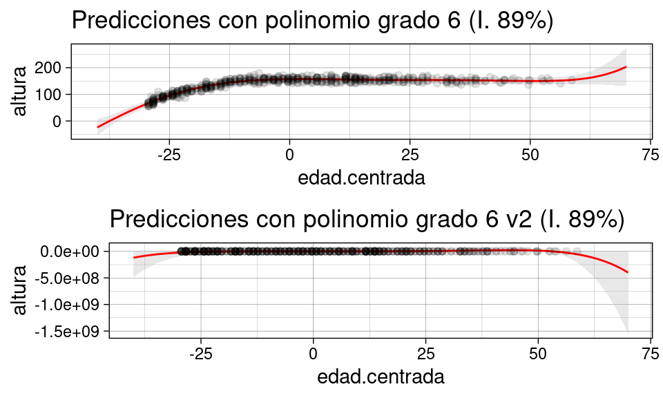

```r
ggarrange(g_g6,g_i_g6,ncol = 1)
```

Y vemos que el segundo modelo está generando predicciones para la altura fuera de lo natural para edades en los extremos de la muestra. Esto se debe al efecto de las distribuciones previas propuestas para los coeficientes $\beta_k$ no permiten generar un buen ajuste respecto a los datos observados.

Posteriormente, realizamos el diagnóstico del modelo con el mismo criterio de información (usando el método loo):

```r
loo_1i_g6<-loo(fit_1i_g6) #calcula: elpd_loo que corresponde a la log-densidad; p_loo: el número efectivo de parámetros; looic: la devianza del modelo así como suss errores estándar (SE) variando sobre todas las observaciones con validación cruzada
loo_1i_g6
```

```
##
## Computed from 4000 by 544 log-likelihood matrix
##
##               Estimate           SE
## elpd_loo -7.665590e+14 8.465869e+13
## p_loo     7.665590e+14 8.465869e+13
## looic     1.533118e+15 1.693174e+14
## ------
## Monte Carlo SE of elpd_loo is NA.
##
## Pareto k diagnostic values:
##                          Count Pct.    Min. n_eff
## (-Inf, 0.5]   (good)       0     0.0%  <NA>
##  (0.5, 0.7]   (ok)         0     0.0%  <NA>
##    (0.7, 1]   (bad)        0     0.0%  <NA>
##    (1, Inf)   (very bad) 544   100.0%  1
## See help('pareto-k-diagnostic') for details.
```

En este caso, el diagnóstico arroja que el modelo es muy malo lo cual hace sentido con el gráfico que vimos arriba. Ahora procederemos a evaluar el criterio de información de loo que usamos en el inciso anterior generando un comparativo con los resultados de los modelos con polinomios de grado 6.

```r
comparativo_loo_1i<-cbind(loo_1g_g6,loo_1i_g6) #agrupa resultados loo
comparativo_loo_1i #imprime comparativo
```

```
##             loo_1g_g6    loo_1i_g6
## estimates   Numeric,6    Numeric,6
## pointwise   Numeric,2720 Numeric,2720
## diagnostics List,2       List,2
## psis_object NULL         NULL
## elpd_loo    -1898.976    -7.66559e+14
## p_loo       7.46735      7.66559e+14
## looic       3797.952     1.533118e+15
## se_elpd_loo 16.32409     8.465869e+13
## se_p_loo    0.7379343    8.465869e+13
## se_looic    32.64818     1.693174e+14
```

Identificamos que el desempeño del modelo con la distribución por default tiene la mejor capacidad predictiva, dado que su devianza (looic) es claramente menor que la del polinomio con las distribuciones propuestas. En términos de la estimación del número efectivo de parámetros (p_loo) vemos que el modelo con polinomios grado 6 y default califica con 7.5 términos efectivos mientras que el modelo con las distribuciones previas propuestas para los coeficientes beta tienen valores exageradamente grandes, esto sugeriría que para poder brindar un mejor ajuste se tendrían que incorporar más parámetros al modelo dado que la desviación están de los coeficientes actual $\sqrt{5})$ es demasiado chica para que los coeficientes de los polinomios puedan tener valores más adecuados para las predicciones.

Por último sólo calculamos el comparativo de diferencia sobre la log-densidad predictiva.

```r
comparativo_diff_loo_1i<-loo_compare(loo_1g_g6,loo_1i_g6) #calcula comparativo de diferencia en términos de la log-densidad predictiva y un error estándar sobre esta diferencia (se_diff). Ordenando los modelos del mejor al peor
comparativo_diff_loo_1i
```

```
##           elpd_diff     se_diff
## fit_1f_g6  0.000000e+00  0.000000e+00
## fit_1i_g6 -7.665590e+14  8.465869e+13
```

Y observamos que la diferencia en términos de la log-densidad predictiva también es muy alta así como el error estándar asociado.

## Datos: Vinos.

Consideremos el conjunto de datos en `vinos.txt`. Estos datos son evaluaciones de 20 vinos diferentes, tanto franceses y estadounidenses, realizadas por 9 jueces (también, franceses y estadounidenses) diferentes. El objetivo de este ejercicio es modelar el `score`, la calificación subjetiva que cada juez asigna a cada vino. Recomiendo centrarlo para el ajuste de los modelos.

### Lectura de los datos

```r
## Definición de semilla
SEED <- 1234

## Lectura de los datos
data_vinos <- read.table("vinos.txt", sep=";", header=TRUE)

## Creando columna con variable "score" centrada
data_vinos <- data_vinos %>%
  mutate(
    score_c = score - mean(score),
    judge = ifelse(judge.amer == 1, paste0(judge, " (AM)"), paste0(judge, " (FR)")),
    wine = ifelse(wine.amer == 1, paste0(wine, " (AM)"), paste0(wine, " (FR)")),
  ) %>%
  mutate(
    wine = ifelse(flight == "white", paste0(wine, " - white"), paste0(wine, " - red")),
  )

data_vinos
```

```
##                    judge flight            wine score wine.amer judge.amer
## 1   Jean-M Cardebat (FR)  white A1 (AM) - white  10.0         1          0
## 2   Jean-M Cardebat (FR)  white B1 (AM) - white  13.0         1          0
## 3   Jean-M Cardebat (FR)  white C1 (FR) - white  14.0         0          0
## 4   Jean-M Cardebat (FR)  white D1 (FR) - white  15.0         0          0
## 5   Jean-M Cardebat (FR)  white E1 (AM) - white   8.0         1          0
## 6   Jean-M Cardebat (FR)  white F1 (AM) - white  13.0         1          0
## 7   Jean-M Cardebat (FR)  white G1 (AM) - white  15.0         1          0
## 8   Jean-M Cardebat (FR)  white H1 (FR) - white  11.0         0          0
## 9   Jean-M Cardebat (FR)  white I1 (AM) - white   9.0         1          0
## 10  Jean-M Cardebat (FR)  white J1 (FR) - white  12.0         0          0
## 11     Tyler Colman (AM)  white A1 (AM) - white  16.0         1          1
## 12     Tyler Colman (AM)  white B1 (AM) - white  14.0         1          1
## 13     Tyler Colman (AM)  white C1 (FR) - white  14.0         0          1
## 14     Tyler Colman (AM)  white D1 (FR) - white  16.0         0          1
```

[output cut: 347 more lines]

### Exploración inicial de los datos

```r
#### Explorando predictores
print("Nombres de los jueces en el set de datos: ")
```

```
## [1] "Nombres de los jueces en el set de datos: "
```

```r
unique(data_vinos$judge)
```

```
## [1] "Jean-M Cardebat (FR)" "Tyler Colman (AM)"    "John Foy (AM)"
## [4] "Olivier Gergaud (FR)" "Robert Hodgson (AM)"  "Linda Murphy (AM)"
## [7] "Daniele Meulder (FR)" "Jamal Rayyis (FR)"    "Francis Schott (AM)"
```

```r
cat("\n")
```

```r
print("Conteo de jueces por nacionalidad: ")
```

```
## [1] "Conteo de jueces por nacionalidad: "
```

```r
paste0("Franceses: ", length(grep("(FR)", unique(data_vinos$judge))))
```

```
## [1] "Franceses: 4"
```

```r
paste0("Americanos: ", length(grep("(AM)", unique(data_vinos$judge))))
```

```
## [1] "Americanos: 5"
```

```r
cat("\n")
```

```r
print("Vinos incorporados en la competencia: ")
```

```
## [1] "Vinos incorporados en la competencia: "
```

```r
unique(data_vinos$wine)
```

```
##  [1] "A1 (AM) - white" "B1 (AM) - white" "C1 (FR) - white" "D1 (FR) - white"
##  [5] "E1 (AM) - white" "F1 (AM) - white" "G1 (AM) - white" "H1 (FR) - white"
##  [9] "I1 (AM) - white" "J1 (FR) - white" "A2 (FR) - red"   "B2 (FR) - red"
## [13] "C2 (AM) - red"   "D2 (AM) - red"   "E2 (AM) - red"   "F2 (AM) - red"
## [17] "G2 (FR) - red"   "H2 (AM) - red"   "I2 (AM) - red"   "J2 (FR) - red"
```

```r
cat("\n")
```

```r
print("Conteo de vinos por nacionalidad: ")
```

```
## [1] "Conteo de vinos por nacionalidad: "
```

```r
paste0("Franceses: ", length(grep("(FR)", unique(data_vinos$wine))))
```

```
## [1] "Franceses: 8"
```

```r
paste0("Americanos: ", length(grep("(AM)", unique(data_vinos$wine))))
```

```
## [1] "Americanos: 12"
```

```r
cat("\n")
```

```r
print("Tipos de vinos en la competencia: ")
```

```
## [1] "Tipos de vinos en la competencia: "
```

```r
unique(data_vinos$flight)
```

```
## [1] "white" "red"
```

```r
cat("\n")
```

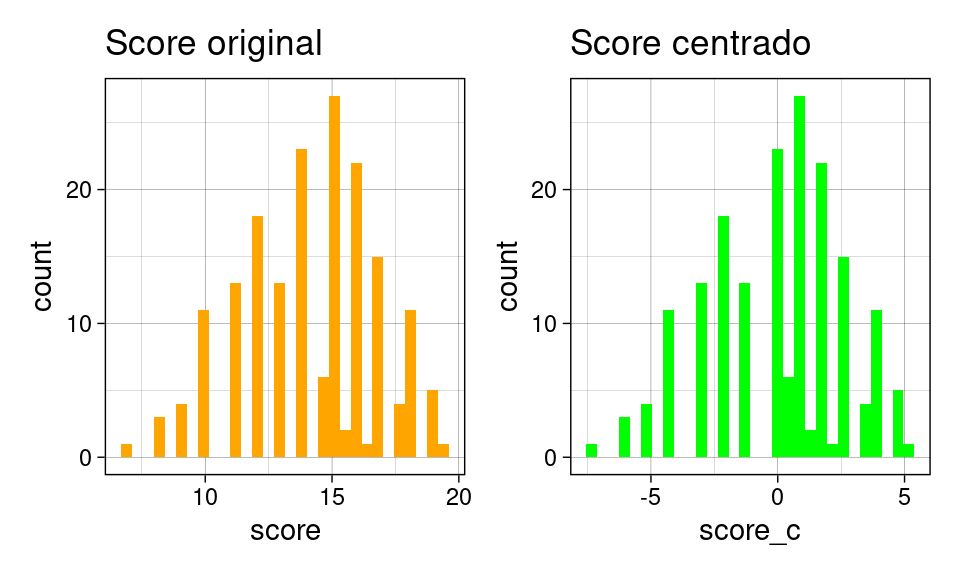

```r
#### Explorando la distribución de scores
bx1 <- data_vinos %>%
    ggplot(
        aes(score)
    ) + geom_histogram(fill="orange") +
  labs(title="Score original")

bx2 <- data_vinos %>%
    ggplot(
        aes(score_c)
    ) + geom_histogram(fill="green") +
  labs(title="Score centrado")

bx1 + bx2
```

### Evaluación del comportamiento de los datos

```r
## Exploración de calificaciones según los jueces (judge)
data_vinos %>%
  group_by(judge) %>%
  summarise(
    mean = mean(score_c),
    n(),
    max(score_c),
    min(score_c)
  ) %>%
  arrange(mean)
```

```
## # A tibble: 9 x 5
##   judge                  mean `n()` `max(score_c)` `min(score_c)`
##   <chr>                 <dbl> <int>          <dbl>          <dbl>
## 1 Robert Hodgson (AM)  -2.00     20            2.8          -6.20
## 2 Jean-M Cardebat (FR) -1.65     20            1.8          -6.20
## 3 Tyler Colman (AM)    -1.05     20            1.8          -3.20
## 4 Daniele Meulder (FR) -0.850    20            1.8          -4.20
## 5 Olivier Gergaud (FR)  0.4      20            4.8          -5.20
## 6 Jamal Rayyis (FR)     0.625    20            5.3          -2.20
## 7 Francis Schott (AM)   0.65     20            4.8          -7.2
## 8 Linda Murphy (AM)     1.45     20            3.8          -1.20
## 9 John Foy (AM)         2.43     20            4.8           0.3
```

```r
## Exploración de calificaciones según el vino (wine)
data_vinos %>%
  group_by(wine) %>%
  summarise(
    mean = mean(score_c),
    n(),
    max(score_c),
    min(score_c)
  ) %>%
  arrange(desc(mean))
```

```
## # A tibble: 20 x 5
##    wine               mean `n()` `max(score_c)` `min(score_c)`
##    <chr>             <dbl> <int>          <dbl>          <dbl>
##  1 B2 (FR) - red    1.63       9            5.3          -3.20
##  2 J2 (FR) - red    1.13       9            3.8          -3.20
##  3 D1 (FR) - white  0.856      9            3.8          -4.20
##  4 B1 (AM) - white  0.8        9            4.8          -3.20
##  5 D2 (AM) - red    0.8        9            3.8          -2.20
##  6 A1 (AM) - white  0.411      9            2.8          -4.20
##  7 E2 (AM) - red    0.356      9            4.8          -2.20
##  8 A2 (FR) - red    0.3        9            4.8          -4.20
##  9 E1 (AM) - white  0.244      9            4.8          -6.20
## 10 G2 (FR) - red    0.0222     9            3.8          -4.20
## 11 F1 (AM) - white -0.0333     9            3.8          -4.20
## 12 F2 (AM) - red   -0.0889     9            2.8          -3.20
## 13 G1 (AM) - white -0.311      9            2.8          -5.20
## 14 C1 (FR) - white -0.367      9            2.8          -2.20
## 15 I1 (AM) - white -0.422      9            3.8          -5.20
## 16 J1 (FR) - white -0.478      9            3.3          -4.20
## 17 H2 (AM) - red   -0.589      9            3.8          -4.20
## 18 H1 (FR) - white -0.644      9            2.8          -5.20
## 19 C2 (AM) - red   -1.09       9            3.8          -6.20
## 20 I2 (AM) - red   -2.53       9            2.8          -7.2
```

```r
## Exploración de calificaciones según el tipo de vino (flight)
data_vinos %>%
  group_by(flight) %>%
  summarise(
    mean(score_c),
    n(),
    max(score_c),
    min(score_c)
  )
```

```
## # A tibble: 2 x 5
##   flight `mean(score_c)` `n()` `max(score_c)` `min(score_c)`
##   <chr>            <dbl> <int>          <dbl>          <dbl>
## 1 red           -0.00556    90            5.3          -7.2
## 2 white          0.00556    90            4.8          -6.20
```

```r
t.test(
  filter(data_vinos, flight == "red")$score_c, filter(data_vinos, flight != "red")$score_c
)
```

```
##
##  Welch Two Sample t-test
##
## data:  filter(data_vinos, flight == "red")$score_c and filter(data_vinos, flight != "red")$score_c
## t = -0.027901, df = 176.67, p-value = 0.9778
## alternative hypothesis: true difference in means is not equal to 0
## 95 percent confidence interval:
##  -0.7970148  0.7747926
## sample estimates:
##    mean of x    mean of y
## -0.005555556  0.005555556
```

**Aquí podemos observar que no hay una diferencia relevante en las calificaciones según el tipo de vino (rojo o blanco).**

```r
## Exploración de las calificaciones por el origen del vino (wine.amer)
data_vinos %>%
  group_by(wine.amer) %>%
  summarise(
    n(),
    mean(score_c),
    min(score_c),
    max(score_c)
  )
```

```
## # A tibble: 2 x 5
##   wine.amer `n()` `mean(score_c)` `min(score_c)` `max(score_c)`
##       <int> <int>           <dbl>          <dbl>          <dbl>
## 1         0    72           0.307          -5.20            5.3
## 2         1   108          -0.205          -7.2             4.8
```

```r
t.test(filter(data_vinos, wine.amer == 0)$score_c, filter(data_vinos, wine.amer == 1)$score_c)
```

```
##
##  Welch Two Sample t-test
##
## data:  filter(data_vinos, wine.amer == 0)$score_c and filter(data_vinos, wine.amer == 1)$score_c
## t = 1.2821, df = 159.4, p-value = 0.2017
## alternative hypothesis: true difference in means is not equal to 0
## 95 percent confidence interval:
##  -0.2764486  1.2995967
## sample estimates:
##  mean of x  mean of y
##  0.3069444 -0.2046296
```

**Aquí vemos que tampoco hay una diferencia muy grande en las calificaciones según el origen del vino.**

```r
## Evaluar si hay alguna diferencia importante entre los vinos según origen y tipo (wine.amer + flight)
data_vinos %>%
  group_by(wine.amer, flight) %>%
  summarise(
    n(),
    mean(score_c),
    min(score_c),
    max(score_c)
  )
```

```
## # A tibble: 4 x 6
## # Groups:   wine.amer [2]
##   wine.amer flight `n()` `mean(score_c)` `min(score_c)` `max(score_c)`
##       <int> <chr>  <int>           <dbl>          <dbl>          <dbl>
## 1         0 red       36           0.772          -4.20            5.3
## 2         0 white     36          -0.158          -5.20            3.8
## 3         1 red       54          -0.524          -7.2             4.8
## 4         1 white     54           0.115          -6.20            4.8
```

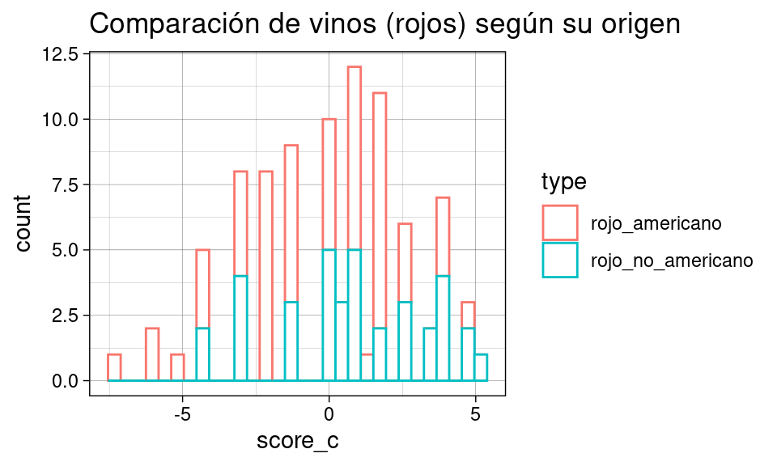

```r
## Evaluando diferencias en vinos rojos dependiendo de su origen.
amer_red <- data.frame(
  score_c = filter(data_vinos, wine.amer == 1, flight == "red")$score_c,
  type = "rojo_americano"
)

nonamer_red <- data.frame(
  score_c = filter(data_vinos, wine.amer == 0, flight == "red")$score_c,
  type = "rojo_no_americano"
)

rbind(amer_red, nonamer_red) %>%
  ggplot(
    aes(x=score_c, color=type)
  ) + geom_histogram(fill="white") +
  labs(title="Comparación de vinos (rojos) según su origen")
```

```r
t.test(filter(data_vinos, wine.amer == 1, flight == "red")$score_c, filter(data_vinos, wine.amer == 0, flight == "red")$score_c)
```

```
##
##  Welch Two Sample t-test
##
## data:  filter(data_vinos, wine.amer == 1, flight == "red")$score_c and filter(data_vinos, wine.amer == 0, flight == "red")$score_c
## t = -2.2296, df = 77.416, p-value = 0.02867
## alternative hypothesis: true difference in means is not equal to 0
## 95 percent confidence interval:
##  -2.4539079 -0.1386847
## sample estimates:
##  mean of x  mean of y
## -0.5240741  0.7722222
```

**El resultado de la prueba Welch indica que sí hay una diferencia estadísticamente significativa (asumiendo un valor-p límite de 0.05) en el score de los vinos rojos dependiendo de su origen.**

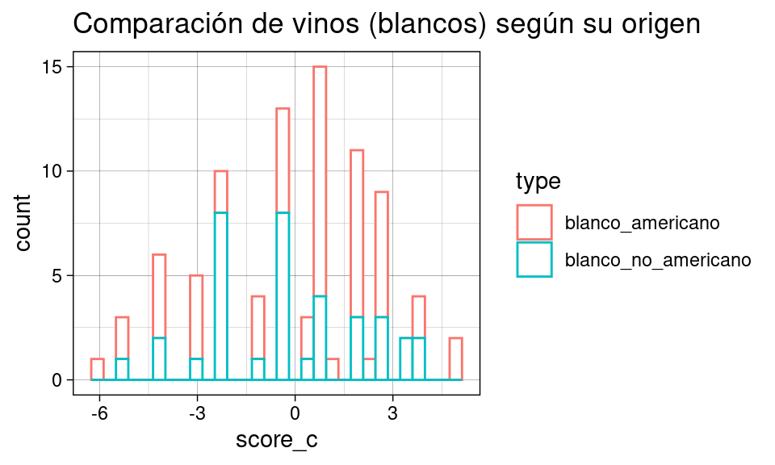

```r
## Evaluando diferencias en vinos blancos dependiendo de su origen.
amer_white <- data.frame(
  score_c = filter(data_vinos, wine.amer == 1, flight == "white")$score_c,
  type = "blanco_americano"
)

nonamer_white <- data.frame(
  score_c = filter(data_vinos, wine.amer == 0, flight == "white")$score_c,
  type = "blanco_no_americano"
)

rbind(amer_white, nonamer_white) %>%
  ggplot(
    aes(x=score_c, color=type)
  ) + geom_histogram(fill="white") +
  labs(title="Comparación de vinos (blancos) según su origen")
```

```r
t.test(filter(data_vinos, wine.amer == 1, flight == "white")$score_c, filter(data_vinos, wine.amer == 0, flight == "white")$score_c)
```

```
##
##  Welch Two Sample t-test
##
## data:  filter(data_vinos, wine.amer == 1, flight == "white")$score_c and filter(data_vinos, wine.amer == 0, flight == "white")$score_c
## t = 0.50693, df = 80.864, p-value = 0.6136
## alternative hypothesis: true difference in means is not equal to 0
## 95 percent confidence interval:
##  -0.7989857  1.3452819
## sample estimates:
##  mean of x  mean of y
##  0.1148148 -0.1583333
```

**Aquí obsservamos que no hay una diferencia estadísticamente significativa en los vinos blancos dependiendo de su origen.**

```r
## Diferencia en las calificaciones según el origen del juez
data_vinos %>%
  group_by(judge.amer) %>%
  summarise(
    n(),
    mean(score_c),
    min(score_c),
    max(score_c)
  )
```

```
## # A tibble: 2 x 5
##   judge.amer `n()` `mean(score_c)` `min(score_c)` `max(score_c)`
##        <int> <int>           <dbl>          <dbl>          <dbl>
## 1          0    80          -0.369          -6.20            5.3
## 2          1   100           0.295          -7.2             4.8
```

```r
amer_judge <- filter(data_vinos, judge.amer == 1)$score_c
nonamer_judge <- filter(data_vinos, judge.amer == 0)$score_c

t.test(amer_judge, nonamer_judge)
```

```
##
##  Welch Two Sample t-test
##
## data:  amer_judge and nonamer_judge
## t = 1.675, df = 171.5, p-value = 0.09576
## alternative hypothesis: true difference in means is not equal to 0
## 95 percent confidence interval:
##  -0.1184473  1.4459473
## sample estimates:
## mean of x mean of y
##   0.29500  -0.36875
```

**Estos resultados nos sugieren que no hay una diferencia importante entre los scores de jueces americanos y no americanos.**

1. En este inciso, sólo considera la variación entre jueces y vinos. Ajusta un modelo de regresión lineal utilizando estos predictores. Justifica tu distribución *a priori*. ¿Cómo interpretas la variación entre jueces individuales y vinos individuales? ¿Notas algún patrón (puedes utilizar `mcmc_areas`)? ¿Qué jueces dieron las calificaciones más altas / más bajas? ¿Qué vinos fueron calificados como peores / mejores en promedio?

**Con el fin de tener una mejor idea de la distribución *a priori* que podríamos usar para nuestro modelo, optamos por ajustar un modelo lineal para poder tener más información de los posibles valores que podrían tomar los coeficientes**

```r
m_2a <- stan_glm(score_c ~ judge + wine,
                 data=data_vinos,
                 seed=SEED,
                 refresh = 0,
               )

print(m_2a)
```

```
## stan_glm
##  family:       gaussian [identity]
##  formula:      score_c ~ judge + wine
##  observations: 180
##  predictors:   28
## ------
##                           Median MAD_SD
## (Intercept)               -0.5    0.9
## judgeFrancis Schott (AM)   1.5    0.7
## judgeJamal Rayyis (FR)     1.5    0.7
## judgeJean-M Cardebat (FR) -0.8    0.7
## judgeJohn Foy (AM)         3.3    0.7
## judgeLinda Murphy (AM)     2.3    0.7
## judgeOlivier Gergaud (FR)  1.3    0.7
## judgeRobert Hodgson (AM)  -1.1    0.7
## judgeTyler Colman (AM)    -0.2    0.7
## wineA2 (FR) - red         -0.1    1.1
## wineB1 (AM) - white        0.4    1.1
## wineB2 (FR) - red          1.3    1.1
## wineC1 (FR) - white       -0.7    1.1
## wineC2 (AM) - red         -1.5    1.1
## wineD1 (FR) - white        0.5    1.1
## wineD2 (AM) - red          0.4    1.1
## wineE1 (AM) - white       -0.2    1.1
## wineE2 (AM) - red          0.0    1.1
## wineF1 (AM) - white       -0.4    1.1
## wineF2 (AM) - red         -0.5    1.1
## wineG1 (AM) - white       -0.7    1.1
## wineG2 (FR) - red         -0.4    1.1
## wineH1 (FR) - white       -1.1    1.1
## wineH2 (AM) - red         -1.0    1.0
## wineI1 (AM) - white       -0.8    1.1
## wineI2 (AM) - red         -2.9    1.1
## wineJ1 (FR) - white       -0.8    1.1
## wineJ2 (FR) - red          0.7    1.1
##
## Auxiliary parameter(s):
##       Median MAD_SD
## sigma 2.3    0.1
##
## ------
## * For help interpreting the printed output see ?print.stanreg
## * For info on the priors used see ?prior_summary.stanreg
```

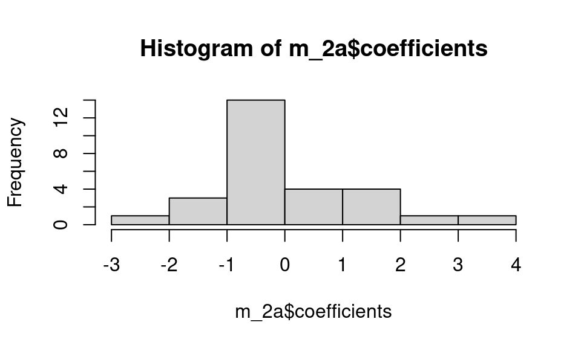

```r
## Exploración de los coeficientes para definir distribución a priori.
hist(m_2a$coefficients)
```

```r
MASS::fitdistr(m_2a$coefficients, "normal")
```

```
##       mean          sd
##   -0.0102219    1.2370920
##  ( 0.2337884) ( 0.1653134)
```

```r
## Ajuste de modelo con distribución _a priori_ seleccionada.
m_2a <- stan_glm(score_c ~ judge + wine,
                 prior=normal(-0.1, 1.24),
                 data=data_vinos,
                 seed=SEED,
                 refresh = 0,
               )

print(m_2a)
```

```
## stan_glm
##  family:       gaussian [identity]
##  formula:      score_c ~ judge + wine
##  observations: 180
##  predictors:   28
## ------
##                           Median MAD_SD
## (Intercept)               -0.2    0.4
## judgeFrancis Schott (AM)   0.8    0.6
## judgeJamal Rayyis (FR)     0.8    0.5
## judgeJean-M Cardebat (FR) -1.2    0.5
## judgeJohn Foy (AM)         2.3    0.6
## judgeLinda Murphy (AM)     1.5    0.6
## judgeOlivier Gergaud (FR)  0.6    0.6
## judgeRobert Hodgson (AM)  -1.5    0.6
## judgeTyler Colman (AM)    -0.7    0.6
## wineA2 (FR) - red          0.1    0.7
## wineB1 (AM) - white        0.4    0.7
## wineB2 (FR) - red          1.1    0.7
## wineC1 (FR) - white       -0.4    0.7
## wineC2 (AM) - red         -0.9    0.7
## wineD1 (FR) - white        0.5    0.7
## wineD2 (AM) - red          0.5    0.7
## wineE1 (AM) - white        0.0    0.7
## wineE2 (AM) - red          0.2    0.7
## wineF1 (AM) - white       -0.2    0.6
## wineF2 (AM) - red         -0.2    0.7
## wineG1 (AM) - white       -0.4    0.7
## wineG2 (FR) - red         -0.1    0.7
## wineH1 (FR) - white       -0.6    0.7
## wineH2 (AM) - red         -0.6    0.7
## wineI1 (AM) - white       -0.4    0.7
## wineI2 (AM) - red         -2.0    0.7
## wineJ1 (FR) - white       -0.5    0.7
## wineJ2 (FR) - red          0.7    0.7
##
## Auxiliary parameter(s):
##       Median MAD_SD
## sigma 2.3    0.1
##
## ------
## * For help interpreting the printed output see ?print.stanreg
## * For info on the priors used see ?prior_summary.stanreg
```

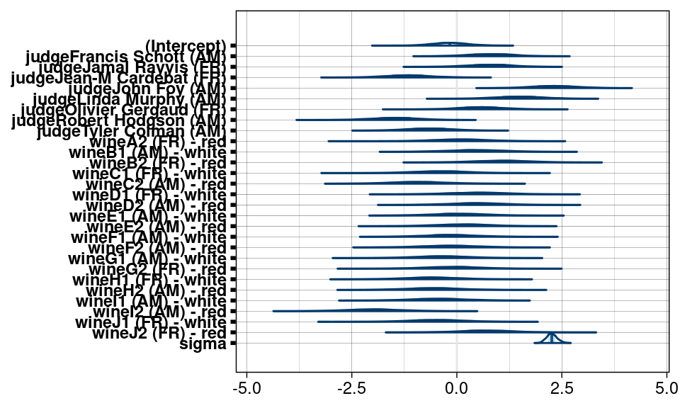

```r
mcmc_areas(m_2a)
```

**Esta visualización nos permite ver la estimación de los intervalos posterior de los coeficientes.** **El modelo toma como referencia al juez Daniele Meulder (FR) y al vino A1 para definir los coeficientes del resto de las variables ascoiadas al modelo.**

**Tomando en consideración estos puntos, podemos hacer las siguientes observaciones:** **1. Los jueces con una desviación positiva fueron menos estrictos al momento de dar una calificación que los jueces que muestran una desviación negativa. Por lo tanto, podemos observar que los jueces más estrictos fueron Jean-M Cardepat y Robert Hodgson en comparación con la referencia que el modelo tomó.** **2. Similar al tema de los jueces, los vinos que tuvieron una desviación negativa fueron los más penalizados, mientras que los que mostraron una desviación positiva fueron los más reconocidos. A diferencia del tema de los jueces, vemos un comportamiento más consistente en los intervalos de los vinos. El único vino que mostró desempeño negativo acorde a la referencia tomada, fue el vino I2 (rojo americano).**

**Es importante notar también que los intervalos mostrados en la gráfica se caracterizan por su amplitud y alineación, lo cual nos sugiere que hay una alta correlación entre las variables del modelo.**

2. Ajusta con la previa *default* en `stan_glm`. Después, ajusta de nuevo el modelo con una distribución a priori regularizada (incorpora `prior = hs()` en las opciones). ¿Que observas al comparar la $R^2$-Bayesiana de ambos modelos? ¿Cómo explicas éste comportamiento? Por otro lado, calcula la capacidad predictiva por medio de `loo` o `waic` (el que tu elijas) en ambos y describe lo que observas en el estadistico que describe el número efectivo de parámetros. ¿Cómo justificas este comportamiento? ¿Cómo concilias lo observado en la $R^2_B$ y la comparación de devianza entre ambas posibilidades?

```r
## Ajustando con previa _default_
m_2b1 <- stan_glm(
  score ~ judge + wine,
  data=data_vinos
)
bR2_m_2b1 <- bayes_R2(m_2b1)

m_2b1
```

```
## stan_glm
##  family:       gaussian [identity]
##  formula:      score ~ judge + wine
##  observations: 180
##  predictors:   28
## ------
##                           Median MAD_SD
## (Intercept)               13.8    0.9
## judgeFrancis Schott (AM)   1.5    0.7
## judgeJamal Rayyis (FR)     1.5    0.7
## judgeJean-M Cardebat (FR) -0.8    0.7
## judgeJohn Foy (AM)         3.3    0.7
## judgeLinda Murphy (AM)     2.3    0.7
## judgeOlivier Gergaud (FR)  1.2    0.7
## judgeRobert Hodgson (AM)  -1.2    0.7
## judgeTyler Colman (AM)    -0.2    0.7
## wineA2 (FR) - red         -0.2    1.1
## wineB1 (AM) - white        0.3    1.1
## wineB2 (FR) - red          1.2    1.1
## wineC1 (FR) - white       -0.8    1.1
## wineC2 (AM) - red         -1.6    1.1
## wineD1 (FR) - white        0.4    1.1
## wineD2 (AM) - red          0.3    1.1
## wineE1 (AM) - white       -0.2    1.1
## wineE2 (AM) - red         -0.1    1.1
## wineF1 (AM) - white       -0.5    1.1
## wineF2 (AM) - red         -0.6    1.1
## wineG1 (AM) - white       -0.8    1.1
## wineG2 (FR) - red         -0.4    1.1
## wineH1 (FR) - white       -1.1    1.1
## wineH2 (AM) - red         -1.0    1.1
## wineI1 (AM) - white       -0.8    1.1
## wineI2 (AM) - red         -3.0    1.1
## wineJ1 (FR) - white       -1.0    1.1
## wineJ2 (FR) - red          0.7    1.1
##
## Auxiliary parameter(s):
##       Median MAD_SD
## sigma 2.3    0.1
##
## ------
## * For help interpreting the printed output see ?print.stanreg
## * For info on the priors used see ?prior_summary.stanreg
```

```r
## Ajustando con distribución a priori regularizada
m_2b2 <- stan_glm(
  score ~ judge + wine,
  data=data_vinos,
  prior=hs()
)
bR2_m_2b2 <- bayes_R2(m_2b2)

m_2b2
```

```
## stan_glm
##  family:       gaussian [identity]
##  formula:      score ~ judge + wine
##  observations: 180
##  predictors:   28
## ------
##                           Median MAD_SD
## (Intercept)               14.0    0.4
## judgeFrancis Schott (AM)   0.4    0.6
## judgeJamal Rayyis (FR)     0.4    0.5
## judgeJean-M Cardebat (FR) -0.9    0.8
## judgeJohn Foy (AM)         2.4    0.7
## judgeLinda Murphy (AM)     1.3    0.8
## judgeOlivier Gergaud (FR)  0.2    0.4
## judgeRobert Hodgson (AM)  -1.4    0.8
## judgeTyler Colman (AM)    -0.3    0.5
## wineA2 (FR) - red          0.0    0.3
## wineB1 (AM) - white        0.1    0.3
## wineB2 (FR) - red          0.6    0.8
## wineC1 (FR) - white        0.0    0.3
## wineC2 (AM) - red         -0.3    0.5
## wineD1 (FR) - white        0.1    0.3
## wineD2 (AM) - red          0.1    0.3
## wineE1 (AM) - white        0.0    0.3
## wineE2 (AM) - red          0.0    0.3
## wineF1 (AM) - white        0.0    0.2
## wineF2 (AM) - red          0.0    0.3
## wineG1 (AM) - white        0.0    0.3
## wineG2 (FR) - red          0.0    0.3
## wineH1 (FR) - white       -0.1    0.3
## wineH2 (AM) - red         -0.1    0.3
## wineI1 (AM) - white        0.0    0.3
## wineI2 (AM) - red         -1.9    0.9
## wineJ1 (FR) - white       -0.1    0.3
## wineJ2 (FR) - red          0.2    0.4
##
## Auxiliary parameter(s):
##       Median MAD_SD
## sigma 2.3    0.1
##
## ------
## * For help interpreting the printed output see ?print.stanreg
## * For info on the priors used see ?prior_summary.stanreg
```

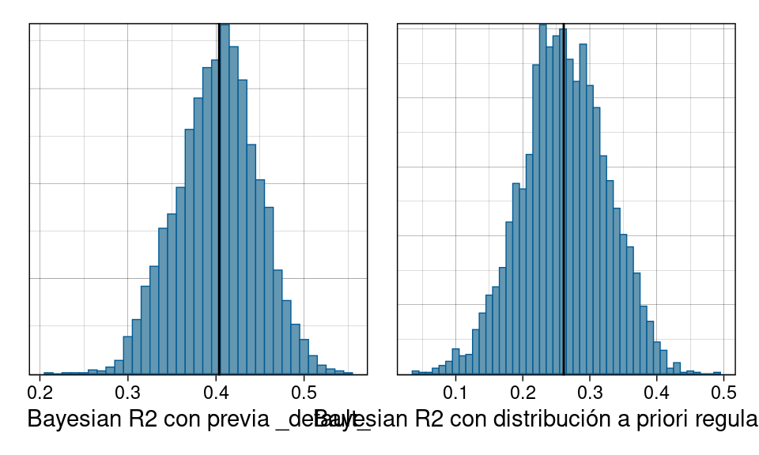

```r
## Gráficas con los resultados
g1 <- mcmc_hist(
  data.frame(bR2_m_2b1),
  binwidth=0.01
)  +
  xlab('Bayesian R2 con previa _default_') +
  geom_vline(xintercept=median(bR2_m_2b1))

g2 <- mcmc_hist(
  data.frame(bR2_m_2b2),
  binwidth=0.01
)  +
  xlab('Bayesian R2 con distribución a priori regularizada') +
  geom_vline(xintercept=median(bR2_m_2b2))

g1 + g2
```

**Al copmarar la R^2-Bayesiana podemos observar que el modelo con una distribución a priori regularizada está cetrado en un valor que el modelo no regularizado. Esto nos hace sentido porque la regularización limita el ajuste al favorecer la simplicidad del modelo. En general, podemos esperar que un modelo regularizado tenga una R^2-Bayesiana más pequeña que un modelo no regularizado.**

```r
## Criterios de información
loo_m_2b1 <- loo(m_2b1)
loo_m_2b2 <- loo(m_2b2)

comp_loo <- cbind(loo_m_2b1, loo_m_2b2)
comp_loo
```

```
##             loo_m_2b1   loo_m_2b2
## estimates   Numeric,6   Numeric,6
## pointwise   Numeric,900 Numeric,900
## diagnostics List,2      List,2
## psis_object NULL        NULL
## elpd_loo    -419.3081   -414.0759
## p_loo       27.37094    17.91391
## looic       838.6163    828.1517
## se_elpd_loo 9.177695    9.090774
## se_p_loo    2.585442    1.967321
## se_looic    18.35539    18.18155
```

**El criterio loo sugiere que el modelo regularizado es preferible sobre el no regularizado porque el primero tiene un valor “elpd_loo” mayor y una desviación estándar menor. Sin embargo, notamos que no hay una diferencia suficientemente grande para que nos sirva como evidencia concluyente.**

3. Ahora considera como predictores `flight`(el tipo de vino), `wine.amer` (de dónde proviene), y `judge.amer` (indicador si el juez es americano). Para este inciso no incluyas las variables de los casos anteriores. De igual manera, justifica la selección de distribución previa que utilizas. ¿Cómo se relacionan estas estimaciones con lo que observaste en el inciso `a`?

```r
## Ajuste de modelo
m_2c <- stan_glm(score_c ~ flight + wine.amer + judge.amer,
                 prior=normal(-0.1, 1.24),
                 data=data_vinos,
                 seed=SEED,
                 refresh = 0,
               )

print(m_2c)
```

```
## stan_glm
##  family:       gaussian [identity]
##  formula:      score_c ~ flight + wine.amer + judge.amer
##  observations: 180
##  predictors:   4
## ------
##             Median MAD_SD
## (Intercept)  0.0    0.4
## flightwhite  0.0    0.4
## wine.amer   -0.5    0.4
## judge.amer   0.6    0.4
##
## Auxiliary parameter(s):
##       Median MAD_SD
## sigma 2.7    0.1
##
## ------
## * For help interpreting the printed output see ?print.stanreg
## * For info on the priors used see ?prior_summary.stanreg
```

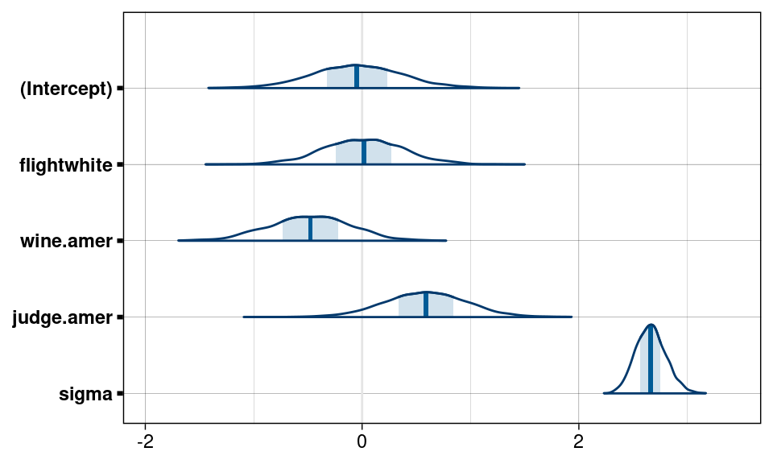

```r
mcmc_areas(m_2c)
```

**A partir de la gráfica de distribuciones posterior podemos observar lo siguiente:** **1. No hay una diferencia relevante en el score dado el tipo de vino (rojo o blanco).** **2. Los jueces americanos tienden a ser un poco menos estrictos que los no americanos.** **3. Los vinos americanos tienden a ser más peores calificados que los no americanos.**

4. Ahora considera todas las posibles interacciones de dos términos con las tres variables de arriba. Explica lo que significa cada término e interpreta los coeficientes. ¿Cómo se relacionan estos resultados con los del inciso `a` de esta sección?

```r
## Ajuste de modelo
m_2d <- stan_glm(score_c ~ flight + wine.amer + judge.amer + flight:wine.amer + flight:judge.amer + wine.amer:judge.amer,
                 prior=normal(-0.1, 1.24),
                 data=data_vinos,
                 seed=SEED,
                 refresh = 0,
               )

print(m_2d)
```

```
## stan_glm
##  family:       gaussian [identity]
##  formula:      score_c ~ flight + wine.amer + judge.amer + flight:wine.amer +
##     flight:judge.amer + wine.amer:judge.amer
##  observations: 180
##  predictors:   7
## ------
##                        Median MAD_SD
## (Intercept)             0.1    0.5
## flightwhite            -0.5    0.6
## wine.amer              -0.8    0.6
## judge.amer              0.7    0.6
## flightwhite:wine.amer   0.9    0.6
## flightwhite:judge.amer  0.0    0.6
## wine.amer:judge.amer   -0.2    0.6
##
## Auxiliary parameter(s):
##       Median MAD_SD
## sigma 2.6    0.1
##
## ------
## * For help interpreting the printed output see ?print.stanreg
## * For info on the priors used see ?prior_summary.stanreg
```

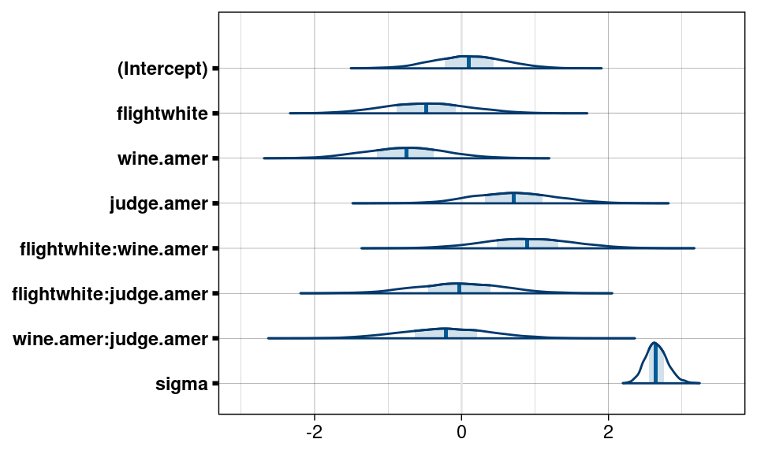

```r
mcmc_areas(m_2d)
```

**Este modelo, el cual ya incorpora sinergias entre las variables, nos permite notar que la conjunción de la variable `flight` y `wine.amer` juega un rol importante en las predicciones del modelo, cosa que no aprovecharíamos en los modelos sin interacciones.** **Los resultados nos siguieren que los jueces americanos tienden a ser más generosos en sus calificaciones que los no americanos. Adicionalmente, también notamos que los vinos americanos tienden a ser más penalizados que los vinos no americanos.**

### Datos:

Utiliza los datos en `nettle.txt` para evaluar la hipótesis de que la diversidad lingüística es producto de la seguridad alimentaria. Los datos contienen mediciones para:

1. `country`: Nombre del país.
2. `num.lang`: Número de lenguajes identificados en dicho país.
3. `area`: Area medida en kilómetros cuadrados.
4. `k.pop`: Población en miles.
5. `num.stations`: Número de estaciones que proveen las siguientes.
6. `mean.growing.season`: Duración promedio de la temporada de cosecha, medida en meses.
7. `sd.growing.season`: Desviación estándar de la duración de la temporada de cosecha, medidad en meses.

La idea es que, en las ecologías productivas, las personas no necesitan grandes redes sociales para protegerse contra el riesgo de escasez de alimentos. Esto significa que los grupos culturales pueden ser más pequeños y más autosuficientes, lo que lleva a más idiomas per cápita. Utiliza el número de idiomas per cápita como resultado:

```r
data <- read.delim("nettle.txt",sep = ";")
data <- data %>%
    mutate(leng.per.cap = num.leng/k.pob)%>%
    mutate(log.leng.per.cap = log(leng.per.cap))%>%
    mutate(log.area = log(area))%>%
    mutate(log.k.pop = log(k.pob))
data
```

```
##                pais num.leng    area  k.pob num.stations mean.growing.season
## 1           Algeria       18 2381741  25660          102                6.60
## 2            Angola       42 1246700  10303           50                6.22
## 3         Australia      234 7713364  17336          134                6.00
## 4        Bangladesh       37  143998 118745           20                7.40
## 5             Benin       52  112622   4889            7                7.14
## 6           Bolivia       38 1098581   7612           48                6.92
## 7          Botswana       27  581730   1348           10                4.60
## 8            Brazil      209 8511965 153322          245                9.71
## 9      Burkina Faso       75  274000   9242            6                5.17
## 10              CAR       94  622984   3127           13                8.08
## 11         Cambodia       18  181035   8442            9                8.44
## 12         Cameroon      275  475422  12239           35                9.17
## 13             Chad      126 1284000   5819           11                4.00
## 14         Colombia       79 1138914  33613           35               11.37
```

[output cut: 135 more lines]

Utilice el logaritmo de esta nueva variable como el objetivo de un modelo de regresión. Este problema tiene un final abierto, lo que les permite decidir cómo abordar las hipótesis y las predicciones inciertas que proporciona el modelo. Si creen que necesita usar WAIC/LOO en cualquier momento, háganlo. Si creen que necesitan cierta distribución previa, argumenten por ella. Si creen que necesitan mostrar las predicciones de cierta manera, háganlo. Traten de evaluar honestamente los efectos principales de la temporada media de crecimiento (`mean.growing.season`) y la desviación de la temporada de crecimiento (`sd.growing.season`), así como su interacción.

### Respuesta:

Para este análisis, se busca explicar los efectos principales de la temporada media de crecimiento (`mean.growing.season`) y la desviación de la temporada de crecimiento (`sd.growing.season`), así como su interacción en el desarrollo de lenguajes en distintas poblaciones.

Primero comenzamos con un breve análisis exploratorio de diferentes variables para entender la relación entre ellas.

Análisis Exploratorio

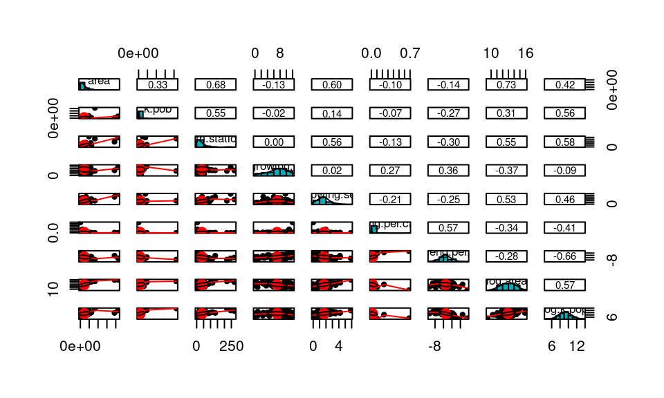

```r
pairs.panels(data[,3:11],
            method = "pearson", # correlation method
             hist.col = "#00AFBB",
             density = TRUE,  # show density plots
             ellipses = TRUE # show correlation ellipses
             )
```

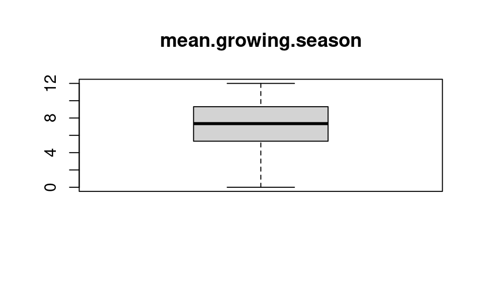

```r
boxplot(data$mean.growing.season, main = "mean.growing.season")
```

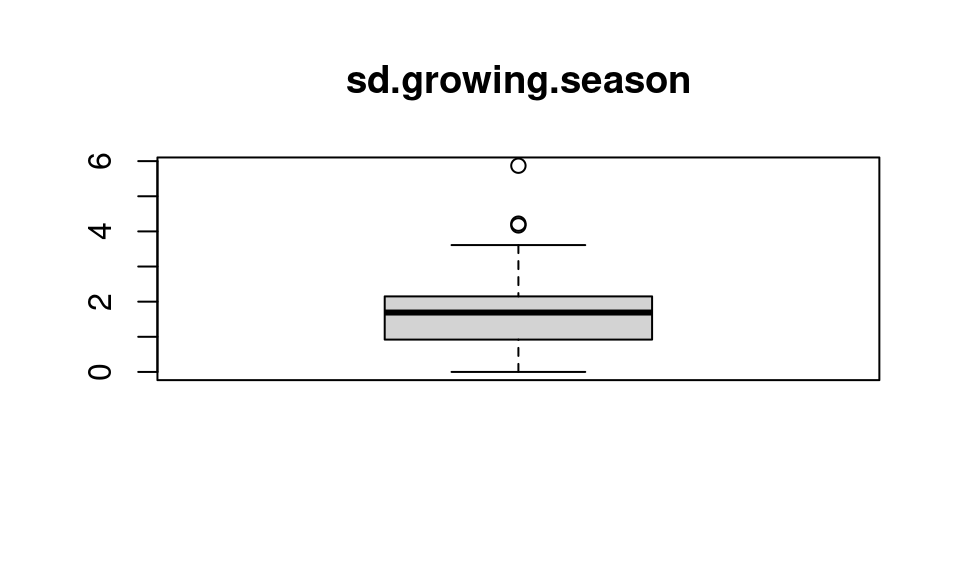

```r
boxplot(data$sd.growing.season, main = "sd.growing.season")
```

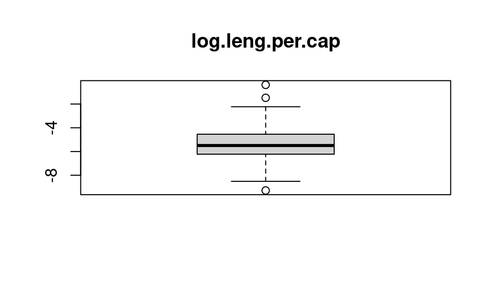

```r
boxplot(data$log.leng.per.cap, main = "log.leng.per.cap" )
```

En este caso, las variables `mean.growing.season` y `sd.growing.season` son mayores o iguales a 0.

```r
###Baseline Model: Only  Mean, SD, Interaction, Area
model1 <- stan_glm(log.leng.per.cap~mean.growing.season+sd.growing.season+mean.growing.season*sd.growing.season+log.area,
                  data = data,
                  prior_intercept = default_prior_intercept("normal"),
                  prior = default_prior_coef("normal"),
                  seed = 108727, refresh = 0)
###Model 2 : Baseline Model + numstations k.pop
model2 <-stan_glm(log.leng.per.cap~mean.growing.season+sd.growing.season+mean.growing.season*sd.growing.season+log.area+num.stations+log.k.pop,
                  data = data,
                  prior_intercept = default_prior_intercept("normal"),
                  prior = default_prior_coef("normal"),
                  seed = 108727, refresh = 0)
###Model 3 : Baseline Model + numstations
model3 <-stan_glm(log.leng.per.cap~mean.growing.season+sd.growing.season+mean.growing.season*sd.growing.season+log.area+num.stations,
                  data = data,
                  prior_intercept = default_prior_intercept("normal"),
                  prior = default_prior_coef("normal"),
                  seed = 108727, refresh = 0)

###Model 4 : Baseline Model + kpop
model4 <-stan_glm(log.leng.per.cap~mean.growing.season+sd.growing.season+mean.growing.season*sd.growing.season+log.area+log.k.pop,
                  data = data,
                 prior_intercept = default_prior_intercept("normal"),
                  prior = default_prior_coef("normal"),
                  seed = 108727, refresh = 0)
```

```r
summary(model1)
```

```
##
## Model Info:
##  function:     stan_glm
##  family:       gaussian [identity]
##  formula:      log.leng.per.cap ~ mean.growing.season + sd.growing.season +
##     mean.growing.season * sd.growing.season + log.area
##  algorithm:    sampling
##  sample:       4000 (posterior sample size)
##  priors:       see help('prior_summary')
##  observations: 74
##  predictors:   5
##
## Estimates:
##                                         mean   sd   10%   50%   90%
## (Intercept)                           -6.9    2.2 -9.7  -6.9  -4.0
## mean.growing.season                    0.3    0.1  0.2   0.3   0.4
## sd.growing.season                      0.4    0.4 -0.1   0.4   0.9
## log.area                               0.0    0.2 -0.2   0.0   0.2
## mean.growing.season:sd.growing.season -0.1    0.0 -0.2  -0.1   0.0
## sigma                                  1.4    0.1  1.2   1.4   1.5
##
## Fit Diagnostics:
##            mean   sd   10%   50%   90%
## mean_PPD -5.5    0.2 -5.7  -5.5  -5.2
##
## The mean_ppd is the sample average posterior predictive distribution of the outcome variable (for details see help('summary.stanreg')).
##
## MCMC diagnostics
##                                       mcse Rhat n_eff
## (Intercept)                           0.0  1.0  2984
## mean.growing.season                   0.0  1.0  1829
## sd.growing.season                     0.0  1.0  1599
## log.area                              0.0  1.0  3172
## mean.growing.season:sd.growing.season 0.0  1.0  1504
## sigma                                 0.0  1.0  3372
## mean_PPD                              0.0  1.0  3225
## log-posterior                         0.0  1.0  1474
##
## For each parameter, mcse is Monte Carlo standard error, n_eff is a crude measure of effective sample size, and Rhat is the potential scale reduction factor on split chains (at convergence Rhat=1).
```

```r
summary(model2)
```

```
##
## Model Info:
##  function:     stan_glm
##  family:       gaussian [identity]
##  formula:      log.leng.per.cap ~ mean.growing.season + sd.growing.season +
##     mean.growing.season * sd.growing.season + log.area + num.stations +
##     log.k.pop
##  algorithm:    sampling
##  sample:       4000 (posterior sample size)
##  priors:       see help('prior_summary')
##  observations: 74
##  predictors:   7
##
## Estimates:
##                                         mean   sd   10%   50%   90%
## (Intercept)                           -5.9    1.8 -8.3  -5.9  -3.6
## mean.growing.season                    0.3    0.1  0.2   0.3   0.4
## sd.growing.season                      0.3    0.3 -0.1   0.3   0.7
## log.area                               0.4    0.1  0.2   0.4   0.6
## num.stations                           0.0    0.0  0.0   0.0   0.0
## log.k.pop                             -0.7    0.1 -0.9  -0.7  -0.6
## mean.growing.season:sd.growing.season -0.1    0.0 -0.1  -0.1   0.0
## sigma                                  1.0    0.1  0.9   1.0   1.1
##
## Fit Diagnostics:
##            mean   sd   10%   50%   90%
## mean_PPD -5.5    0.2 -5.7  -5.5  -5.2
##
## The mean_ppd is the sample average posterior predictive distribution of the outcome variable (for details see help('summary.stanreg')).
##
## MCMC diagnostics
##                                       mcse Rhat n_eff
## (Intercept)                           0.0  1.0  2971
## mean.growing.season                   0.0  1.0  2236
## sd.growing.season                     0.0  1.0  2129
## log.area                              0.0  1.0  2943
## num.stations                          0.0  1.0  3447
## log.k.pop                             0.0  1.0  3191
## mean.growing.season:sd.growing.season 0.0  1.0  2049
## sigma                                 0.0  1.0  3366
## mean_PPD                              0.0  1.0  3529
## log-posterior                         0.1  1.0  1431
##
## For each parameter, mcse is Monte Carlo standard error, n_eff is a crude measure of effective sample size, and Rhat is the potential scale reduction factor on split chains (at convergence Rhat=1).
```

```r
summary(model3)
```

```
##
## Model Info:
##  function:     stan_glm
##  family:       gaussian [identity]
##  formula:      log.leng.per.cap ~ mean.growing.season + sd.growing.season +
##     mean.growing.season * sd.growing.season + log.area + num.stations
##  algorithm:    sampling
##  sample:       4000 (posterior sample size)
##  priors:       see help('prior_summary')
##  observations: 74
##  predictors:   6
##
## Estimates:
##                                         mean   sd    10%   50%   90%
## (Intercept)                            -8.5    2.4 -11.6  -8.5  -5.3
## mean.growing.season                     0.3    0.1   0.2   0.3   0.4
## sd.growing.season                       0.5    0.4   0.0   0.5   1.0
## log.area                                0.1    0.2  -0.1   0.1   0.4
## num.stations                            0.0    0.0   0.0   0.0   0.0
## mean.growing.season:sd.growing.season  -0.1    0.0  -0.2  -0.1   0.0
## sigma                                   1.3    0.1   1.2   1.3   1.5
##
## Fit Diagnostics:
##            mean   sd   10%   50%   90%
## mean_PPD -5.5    0.2 -5.7  -5.5  -5.2
##
## The mean_ppd is the sample average posterior predictive distribution of the outcome variable (for details see help('summary.stanreg')).
##
## MCMC diagnostics
##                                       mcse Rhat n_eff
## (Intercept)                           0.0  1.0  2440
## mean.growing.season                   0.0  1.0  2130
## sd.growing.season                     0.0  1.0  1802
## log.area                              0.0  1.0  2513
## num.stations                          0.0  1.0  2988
## mean.growing.season:sd.growing.season 0.0  1.0  1671
## sigma                                 0.0  1.0  2881
## mean_PPD                              0.0  1.0  3498
## log-posterior                         0.0  1.0  1667
##
## For each parameter, mcse is Monte Carlo standard error, n_eff is a crude measure of effective sample size, and Rhat is the potential scale reduction factor on split chains (at convergence Rhat=1).
```

```r
summary(model4)
```

```
##
## Model Info:
##  function:     stan_glm
##  family:       gaussian [identity]
##  formula:      log.leng.per.cap ~ mean.growing.season + sd.growing.season +
##     mean.growing.season * sd.growing.season + log.area + log.k.pop
##  algorithm:    sampling
##  sample:       4000 (posterior sample size)
##  priors:       see help('prior_summary')
##  observations: 74
##  predictors:   6
##
## Estimates:
##                                         mean   sd   10%   50%   90%
## (Intercept)                           -6.1    1.6 -8.2  -6.1  -4.0
## mean.growing.season                    0.3    0.1  0.2   0.3   0.4
## sd.growing.season                      0.3    0.3  0.0   0.3   0.7
## log.area                               0.4    0.1  0.3   0.4   0.6
## log.k.pop                             -0.7    0.1 -0.9  -0.7  -0.6
## mean.growing.season:sd.growing.season -0.1    0.0 -0.1  -0.1   0.0
## sigma                                  1.0    0.1  0.9   1.0   1.1
##
## Fit Diagnostics:
##            mean   sd   10%   50%   90%
## mean_PPD -5.5    0.2 -5.7  -5.5  -5.2
##
## The mean_ppd is the sample average posterior predictive distribution of the outcome variable (for details see help('summary.stanreg')).
##
## MCMC diagnostics
##                                       mcse Rhat n_eff
## (Intercept)                           0.0  1.0  3615
## mean.growing.season                   0.0  1.0  2406
## sd.growing.season                     0.0  1.0  2003
## log.area                              0.0  1.0  2854
## log.k.pop                             0.0  1.0  3000
## mean.growing.season:sd.growing.season 0.0  1.0  1998
## sigma                                 0.0  1.0  3295
## mean_PPD                              0.0  1.0  3935
## log-posterior                         0.0  1.0  1758
##
## For each parameter, mcse is Monte Carlo standard error, n_eff is a crude measure of effective sample size, and Rhat is the potential scale reduction factor on split chains (at convergence Rhat=1).
```

```r
loo1<-loo(model1)
loo2<-loo(model2)
loo3<-loo(model3)
loo4<-loo(model4)

waic1<-waic(model1)
waic2<-waic(model2)
waic3<-waic(model3)
waic4<-waic(model4)

loo_compare(loo1,loo2,loo3,loo4)
```

```
##        elpd_diff se_diff
## model4   0.0       0.0
## model2  -0.9       0.4
## model1 -23.0       5.2
## model3 -23.1       5.4
```

```r
loo_compare(waic1,waic2,waic3,waic4)
```

```
##        elpd_diff se_diff
## model4   0.0       0.0
## model2  -0.9       0.4
## model3 -22.9       5.4
## model1 -23.0       5.2
```

Además de crear estos modelos, relizamos unas transformaciones a las variables `mean.growing.season`,`sd.growing.season` para centrarlas en su media. Con esto obtenemos las nuevas variables `centered.mean.growing.season`,`centered.sd.growing.season`. En este caso, la interpretación de los coeficientes es un poco distinta.

```r
data_centered = data %>%
              mutate(centered.mean.growing.season= mean.growing.season - mean(mean.growing.season))%>%
              mutate(centered.sd.growing.season= sd.growing.season - mean(sd.growing.season))

###Basline Model: Only  Mean, SD, Interaction, Area
model_centered_1 <- stan_glm(log.leng.per.cap~centered.mean.growing.season+centered.sd.growing.season+centered.mean.growing.season*centered.sd.growing.season+log.area,
                              data = data_centered,
                              prior_intercept = default_prior_intercept("normal"),
                             prior = default_prior_coef("normal"),
                              seed = 108727, refresh = 0)

### Model centered 2: Basline + numstatiosn + logpop
model_centered_2 <- stan_glm(log.leng.per.cap~centered.mean.growing.season+centered.sd.growing.season+centered.mean.growing.season*centered.sd.growing.season+log.area+num.stations+log.k.pop,
                              data = data_centered,
                              prior_intercept = default_prior_intercept("normal"),
                             prior = default_prior_coef("normal"),
                              seed = 108727, refresh = 0)

### Model centered 3: Basline + numstatiosn
model_centered_3 <- stan_glm(log.leng.per.cap~centered.mean.growing.season+centered.sd.growing.season+centered.mean.growing.season*centered.sd.growing.season+log.area+num.stations,
                              data = data_centered,
                              prior_intercept = default_prior_intercept("normal"),
                             prior = default_prior_coef("normal"),
                              seed = 108727, refresh = 0)

### Model centered 4: Basline  + logpop
model_centered_4 <- stan_glm(log.leng.per.cap~centered.mean.growing.season+centered.sd.growing.season+centered.mean.growing.season*centered.sd.growing.season+log.area+log.k.pop,
                              data = data_centered,
                              prior_intercept = default_prior_intercept("normal"),
                             prior = default_prior_coef("normal"),
                              seed = 108727, refresh = 0)
```

```r
summary(model_centered_1)
```

```
##
## Model Info:
##  function:     stan_glm
##  family:       gaussian [identity]
##  formula:      log.leng.per.cap ~ centered.mean.growing.season + centered.sd.growing.season +
##     centered.mean.growing.season * centered.sd.growing.season +
##     log.area
##  algorithm:    sampling
##  sample:       4000 (posterior sample size)
##  priors:       see help('prior_summary')
##  observations: 74
##  predictors:   5
##
## Estimates:
##                                                           mean   sd   10%   50%
## (Intercept)                                             -5.3    2.2 -8.1  -5.3
## centered.mean.growing.season                             0.1    0.1  0.0   0.1
## centered.sd.growing.season                              -0.3    0.2 -0.6  -0.3
## log.area                                                 0.0    0.2 -0.2   0.0
## centered.mean.growing.season:centered.sd.growing.season -0.1    0.0 -0.2  -0.1
## sigma                                                    1.4    0.1  1.2   1.4
##                                                           90%
## (Intercept)                                             -2.5
## centered.mean.growing.season                             0.2
## centered.sd.growing.season                              -0.1
## log.area                                                 0.2
## centered.mean.growing.season:centered.sd.growing.season  0.0
## sigma                                                    1.5
##
## Fit Diagnostics:
##            mean   sd   10%   50%   90%
## mean_PPD -5.5    0.2 -5.7  -5.5  -5.2
##
## The mean_ppd is the sample average posterior predictive distribution of the outcome variable (for details see help('summary.stanreg')).
##
## MCMC diagnostics
##                                                         mcse Rhat n_eff
## (Intercept)                                             0.0  1.0  2585
## centered.mean.growing.season                            0.0  1.0  2724
## centered.sd.growing.season                              0.0  1.0  2700
## log.area                                                0.0  1.0  2580
## centered.mean.growing.season:centered.sd.growing.season 0.0  1.0  3058
## sigma                                                   0.0  1.0  3293
## mean_PPD                                                0.0  1.0  3849
## log-posterior                                           0.0  1.0  1579
##
## For each parameter, mcse is Monte Carlo standard error, n_eff is a crude measure of effective sample size, and Rhat is the potential scale reduction factor on split chains (at convergence Rhat=1).
```

```r
summary(model_centered_2)
```

```
##
## Model Info:
##  function:     stan_glm
##  family:       gaussian [identity]
##  formula:      log.leng.per.cap ~ centered.mean.growing.season + centered.sd.growing.season +
##     centered.mean.growing.season * centered.sd.growing.season +
##     log.area + num.stations + log.k.pop
##  algorithm:    sampling
##  sample:       4000 (posterior sample size)
##  priors:       see help('prior_summary')
##  observations: 74
##  predictors:   7
##
## Estimates:
##                                                           mean   sd   10%   50%
## (Intercept)                                             -4.2    1.7 -6.3  -4.2
## centered.mean.growing.season                             0.2    0.0  0.1   0.2
## centered.sd.growing.season                              -0.1    0.1 -0.3  -0.1
## log.area                                                 0.4    0.1  0.3   0.4
## num.stations                                             0.0    0.0  0.0   0.0
## log.k.pop                                               -0.7    0.1 -0.9  -0.7
## centered.mean.growing.season:centered.sd.growing.season -0.1    0.0 -0.1  -0.1
## sigma                                                    1.0    0.1  0.9   1.0
##                                                           90%
## (Intercept)                                             -2.1
## centered.mean.growing.season                             0.2
## centered.sd.growing.season                               0.0
## log.area                                                 0.6
## num.stations                                             0.0
## log.k.pop                                               -0.6
## centered.mean.growing.season:centered.sd.growing.season  0.0
## sigma                                                    1.1
##
## Fit Diagnostics:
##            mean   sd   10%   50%   90%
## mean_PPD -5.5    0.2 -5.7  -5.5  -5.3
##
## The mean_ppd is the sample average posterior predictive distribution of the outcome variable (for details see help('summary.stanreg')).
##
## MCMC diagnostics
##                                                         mcse Rhat n_eff
## (Intercept)                                             0.0  1.0  3219
## centered.mean.growing.season                            0.0  1.0  3163
## centered.sd.growing.season                              0.0  1.0  3875
## log.area                                                0.0  1.0  3265
## num.stations                                            0.0  1.0  4329
## log.k.pop                                               0.0  1.0  4370
## centered.mean.growing.season:centered.sd.growing.season 0.0  1.0  4354
## sigma                                                   0.0  1.0  3599
## mean_PPD                                                0.0  1.0  4565
## log-posterior                                           0.1  1.0  1376
##
## For each parameter, mcse is Monte Carlo standard error, n_eff is a crude measure of effective sample size, and Rhat is the potential scale reduction factor on split chains (at convergence Rhat=1).
```

```r
summary(model_centered_3)
```

```
##
## Model Info:
##  function:     stan_glm
##  family:       gaussian [identity]
##  formula:      log.leng.per.cap ~ centered.mean.growing.season + centered.sd.growing.season +
##     centered.mean.growing.season * centered.sd.growing.season +
##     log.area + num.stations
##  algorithm:    sampling
##  sample:       4000 (posterior sample size)
##  priors:       see help('prior_summary')
##  observations: 74
##  predictors:   6
##
## Estimates:
##                                                           mean   sd   10%   50%
## (Intercept)                                             -6.8    2.2 -9.6  -6.7
## centered.mean.growing.season                             0.1    0.1  0.1   0.1
## centered.sd.growing.season                              -0.2    0.2 -0.5  -0.2
## log.area                                                 0.1    0.2 -0.1   0.1
## num.stations                                             0.0    0.0  0.0   0.0
## centered.mean.growing.season:centered.sd.growing.season -0.1    0.0 -0.2  -0.1
## sigma                                                    1.3    0.1  1.2   1.3
##                                                           90%
## (Intercept)                                             -3.9
## centered.mean.growing.season                             0.2
## centered.sd.growing.season                               0.0
## log.area                                                 0.4
## num.stations                                             0.0
## centered.mean.growing.season:centered.sd.growing.season  0.0
## sigma                                                    1.5
##
## Fit Diagnostics:
##            mean   sd   10%   50%   90%
## mean_PPD -5.5    0.2 -5.7  -5.5  -5.2
##
## The mean_ppd is the sample average posterior predictive distribution of the outcome variable (for details see help('summary.stanreg')).
##
## MCMC diagnostics
##                                                         mcse Rhat n_eff
## (Intercept)                                             0.0  1.0  3254
## centered.mean.growing.season                            0.0  1.0  2817
## centered.sd.growing.season                              0.0  1.0  3266
## log.area                                                0.0  1.0  3177
## num.stations                                            0.0  1.0  3341
## centered.mean.growing.season:centered.sd.growing.season 0.0  1.0  3322
## sigma                                                   0.0  1.0  3424
## mean_PPD                                                0.0  1.0  3896
## log-posterior                                           0.0  1.0  1622
##
## For each parameter, mcse is Monte Carlo standard error, n_eff is a crude measure of effective sample size, and Rhat is the potential scale reduction factor on split chains (at convergence Rhat=1).
```

```r
summary(model_centered_4)
```

```
##
## Model Info:
##  function:     stan_glm
##  family:       gaussian [identity]
##  formula:      log.leng.per.cap ~ centered.mean.growing.season + centered.sd.growing.season +
##     centered.mean.growing.season * centered.sd.growing.season +
##     log.area + log.k.pop
##  algorithm:    sampling
##  sample:       4000 (posterior sample size)
##  priors:       see help('prior_summary')
##  observations: 74
##  predictors:   6
##
## Estimates:
##                                                           mean   sd   10%   50%
## (Intercept)                                             -4.3    1.6 -6.3  -4.3
## centered.mean.growing.season                             0.2    0.0  0.1   0.2
## centered.sd.growing.season                              -0.1    0.1 -0.3  -0.1
## log.area                                                 0.4    0.1  0.3   0.4
## log.k.pop                                               -0.7    0.1 -0.9  -0.7
## centered.mean.growing.season:centered.sd.growing.season -0.1    0.0 -0.1  -0.1
## sigma                                                    1.0    0.1  0.9   1.0
##                                                           90%
## (Intercept)                                             -2.3
## centered.mean.growing.season                             0.2
## centered.sd.growing.season                               0.0
## log.area                                                 0.6
## log.k.pop                                               -0.6
## centered.mean.growing.season:centered.sd.growing.season  0.0
## sigma                                                    1.1
##
## Fit Diagnostics:
##            mean   sd   10%   50%   90%
## mean_PPD -5.5    0.2 -5.7  -5.5  -5.2
##
## The mean_ppd is the sample average posterior predictive distribution of the outcome variable (for details see help('summary.stanreg')).
##
## MCMC diagnostics
##                                                         mcse Rhat n_eff
## (Intercept)                                             0.0  1.0  3109
## centered.mean.growing.season                            0.0  1.0  2687
## centered.sd.growing.season                              0.0  1.0  2941
## log.area                                                0.0  1.0  2634
## log.k.pop                                               0.0  1.0  2999
## centered.mean.growing.season:centered.sd.growing.season 0.0  1.0  3312
## sigma                                                   0.0  1.0  3389
## mean_PPD                                                0.0  1.0  3797
## log-posterior                                           0.0  1.0  1764
##
## For each parameter, mcse is Monte Carlo standard error, n_eff is a crude measure of effective sample size, and Rhat is the potential scale reduction factor on split chains (at convergence Rhat=1).
```

```r
loo1_centered<-loo(model_centered_1)
loo2_centered<-loo(model_centered_2)
loo3_centered<-loo(model_centered_3)
loo4_centered<-loo(model_centered_4)
#loo5_centered<-loo(model_centered_5)

waic1_centered<-waic(model_centered_1)
waic2_centered<-waic(model_centered_2)
waic3_centered<-waic(model_centered_3)
waic4_centered<-waic(model_centered_4)
#waic5_centered<-waic(model_centered_5)

loo_compare(loo1_centered,loo2_centered,loo3_centered,loo4_centered)
```

```
##                  elpd_diff se_diff
## model_centered_4   0.0       0.0
## model_centered_2  -1.1       0.4
## model_centered_3 -23.0       5.4
## model_centered_1 -23.3       5.2
```

```r
loo_compare(waic1_centered,waic2_centered,waic3_centered,waic4_centered)
```

```
##                  elpd_diff se_diff
## model_centered_4   0.0       0.0
## model_centered_2  -1.1       0.3
## model_centered_3 -22.8       5.3
## model_centered_1 -23.4       5.1
```

```r
loo_compare(loo1,loo2,loo3,loo4,loo1_centered,loo2_centered,loo3_centered,loo4_centered)
```

```
##                  elpd_diff se_diff
## model_centered_4   0.0       0.0
## model4            -0.2       0.1
## model2            -1.1       0.4
## model_centered_2  -1.1       0.4
## model_centered_3 -23.0       5.4
## model1           -23.2       5.2
## model3           -23.3       5.4
## model_centered_1 -23.3       5.2
```

```r
loo_compare(waic1,waic2,waic3,waic4,waic1_centered,waic2_centered,waic3_centered,waic4_centered)
```

```
##                  elpd_diff se_diff
## model_centered_4   0.0       0.0
## model4            -0.2       0.1
## model2            -1.1       0.4
## model_centered_2  -1.1       0.3
## model_centered_3 -22.8       5.3
## model3           -23.1       5.4
## model1           -23.2       5.1
## model_centered_1 -23.4       5.1
```

```r
print(loo4)
```

```
##
## Computed from 4000 by 74 log-likelihood matrix
##
##          Estimate   SE
## elpd_loo   -108.5  8.3
## p_loo         7.2  1.7
## looic       216.9 16.6
## ------
## Monte Carlo SE of elpd_loo is 0.1.
##
## Pareto k diagnostic values:
##                          Count Pct.    Min. n_eff
## (-Inf, 0.5]   (good)     71    95.9%   953
##  (0.5, 0.7]   (ok)        3     4.1%   362
##    (0.7, 1]   (bad)       0     0.0%   <NA>
##    (1, Inf)   (very bad)  0     0.0%   <NA>
##
## All Pareto k estimates are ok (k < 0.7).
## See help('pareto-k-diagnostic') for details.
```

```r
print(loo4_centered)
```

```
##
## Computed from 4000 by 74 log-likelihood matrix
##
##          Estimate   SE
## elpd_loo   -108.3  8.3
## p_loo         7.0  1.7
## looic       216.6 16.6
## ------
## Monte Carlo SE of elpd_loo is 0.1.
##
## Pareto k diagnostic values:
##                          Count Pct.    Min. n_eff
## (-Inf, 0.5]   (good)     73    98.6%   749
##  (0.5, 0.7]   (ok)        1     1.4%   408
##    (0.7, 1]   (bad)       0     0.0%   <NA>
##    (1, Inf)   (very bad)  0     0.0%   <NA>
##
## All Pareto k estimates are ok (k < 0.7).
## See help('pareto-k-diagnostic') for details.
```

```r
print(waic4)
```

```
##
## Computed from 4000 by 74 log-likelihood matrix
##
##           Estimate   SE
## elpd_waic   -108.3  8.3
## p_waic         7.0  1.7
## waic         216.6 16.5
##
## 4 (5.4%) p_waic estimates greater than 0.4. We recommend trying loo instead.
```

```r
print(waic4_centered)
```

```
##
## Computed from 4000 by 74 log-likelihood matrix
##
##           Estimate   SE
## elpd_waic   -108.1  8.3
## p_waic         6.8  1.6
## waic         216.2 16.5
##
## 3 (4.1%) p_waic estimates greater than 0.4. We recommend trying loo instead.
```

En conclusión, tenemos que el mejor modelo es el `model_centered_4` por un pequeño margen utilizando el criterio de loo como indicador. Tenemos que este modelo es el que tiene mayor log-densidad predictiva. Además, el hecho de que contenga variables centradas, no afecta la interpretación de los coeficientes en cuanto a que ayuda a responder las hipótesis planteadas más adelante. Hay un punto importante a resaltar, el valor de 0 tanto en `mean.growing.season` y `sd.growing.season` sí tienen una interpretación, es decir que no tienen temporada de crecimiento y que no existe variabilidad en ella. Sin embargo, al estudiar los datos, esto sólo se presenta en dos observaciones y es un valor poco frecuente. Dado que los datos incluyen únicamente países ubicados dentro de los trópicos, se decidió usar el modelo con variables centradas ya que se prefiere interpretar los coeficientes como el cambio en la diversidad linguística con respecto a la desviación de la duración de la temporada promedio o la variabilidad promedio. En otras palabras, no nos importa tanto el valor de la temporada de crecimiento (o variabilidad) en sí, sino que más larga o corta es con respecto a los demás. Además, se está controlando por la interacción entre ambas variables.

El modelo resultante es el siguiente:

$$\hat{y}= \hat\beta_0 + \hat\beta_1(x_1-\bar x_1)+\hat\beta_2(x_2-\bar x_2) + \hat\beta_3(x_1-\bar x_1)*(x_2-\bar x_2)+\hat\beta_4 x_4+\hat\beta_5 x_5$$

Con $x_1 = $ temporada de crecimiento y x_2 = $ variabilidad en temporada de crecimiento.

Por lo tanto, ante un cambio en $x_1$ $y $ cambia en $\hat\beta_1+\hat\beta_3*(x_2-\bar x_2)$ unidades y ante un cambio en $x_2$ $y $ cambia en $\hat\beta_2+\hat\beta_3*(x_1-\bar x_1)$ unidades.

Dado que $y$ es una transformación logarítmica de la variable de lenguajes per capita, si buscamos predecir esta variable es necesario hacer la siguiente transformacion del modelo:

Si z es lenguajes per capita
$$y = \ln(z)$$
$$y= \beta_0 + \beta_1(x_1-\bar x_1)+\beta_2(x_2-\bar x_2) + \beta_3(x_1-\bar x_1)*(x_2-\bar x_2)+\beta_4 x_4+\beta_5 x_5 +\epsilon$$
Se obtiene que:

$$z= e^{\beta_0 + \beta_1(x_1-\bar x_1)+\beta_2(x_2-\bar x_2) + \beta_3(x_1-\bar x_1)*(x_2-\bar x_2)+\beta_4 x_4+\beta_5 x_5 +\epsilon}$$
Como el modelo solo busca probar ciertas hipótesis y no predecir, no es necesario realizar esta transformación.

1. Evalúe la hipótesis de que la diversidad lingüística, medida por `log(lang.per.cap)`, está asociada positivamente con la duración promedio de la temporada de crecimiento, `mean.growing.season`. Considera tambíen `log(area)` en tu modelo (no como una interacción). Interpreten sus resultados.

La hipotesis de que la diversidad lingüística, medida por `log(lang.per.cap)`, está asociada positivamente con la duración promedio de la temporada de crecimiento, `mean.growing.season` es correcta. En este modelo se observa que el coeficiente asociado a la variable `centered.mean.growing.season` es positivo. La interpretacion es que en pais, mientras mas dure la temporada de crecimiento relativo a los valores promedio, mayor sera la diversidad linguistica. Esto quiere decir que mientras más larga sea la temprorada de crecimiento mayor será la diversidad linguística. Además observamos que la distribucion posterior del coeficiente asociado a la variable `centered.mean.growing.season` será positivo con un 90% de probabilidad ya que su intervalo de confianza va de 0.089 a 0.239.

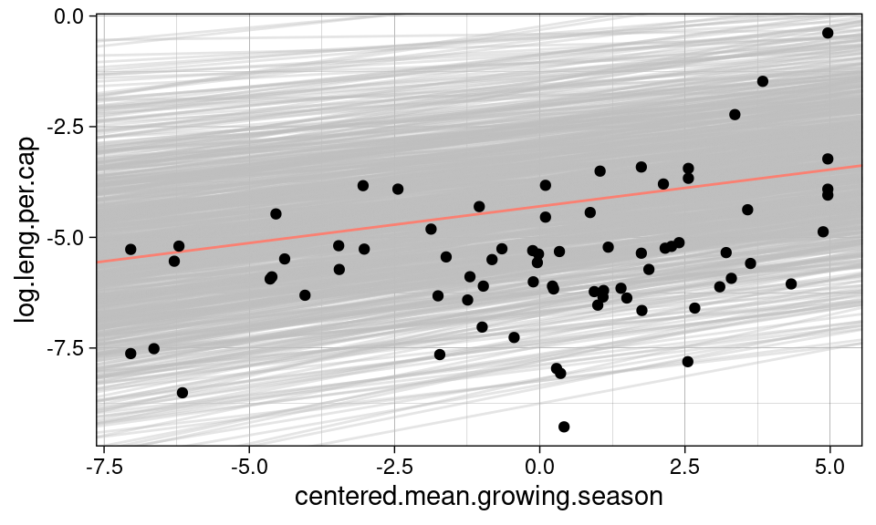

```r
ggplot(data = data_centered, aes(x = centered.mean.growing.season, y = log.leng.per.cap))  +
    geom_abline(data = as_tibble(model_centered_4) %>% sample_frac(.2),
                aes(slope = centered.mean.growing.season, intercept = `(Intercept)`),
                color = 'grey', alpha = .4) +
    geom_abline(slope = coef(model_centered_4)[2], intercept = coef(model_centered_4)[1], color = 'salmon') +
    geom_point()
```

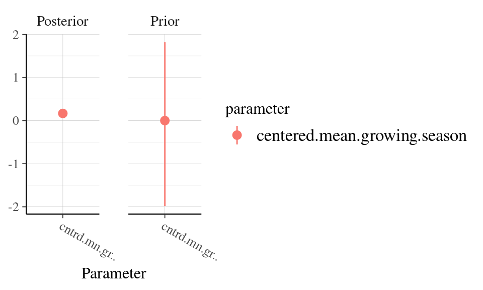

```r
posterior_vs_prior(model_centered_4,pars= c("centered.mean.growing.season"))
```

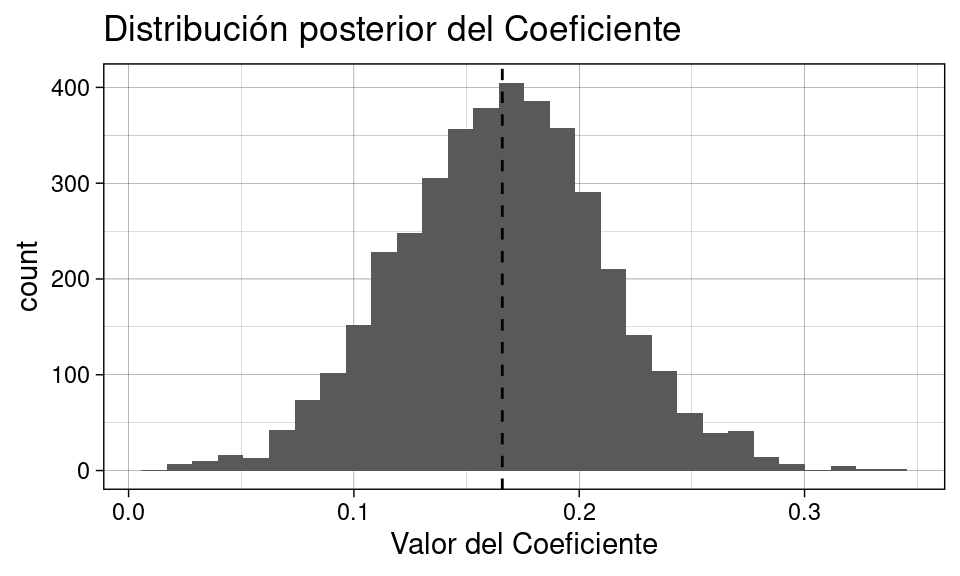

```r
as_tibble(model_centered_4)%>%
    ggplot(aes(x = centered.mean.growing.season)) +
        geom_histogram() +
        geom_vline(xintercept = coef(model_centered_4)[2], lty = 2) +
        xlab("Valor del Coeficiente")+
        ggtitle("Distribución posterior del Coeficiente")
```

```r
posterior_interval(model_centered_4,pars= c("centered.mean.growing.season"))
```

```
##                                      5%       95%
## centered.mean.growing.season 0.08986091 0.2395738
```

2. Ahora evalúen la hipótesis de que la diversidad lingüística está asociada negativamente con la desviación estándar de la duración de la temporada de crecimiento. Esta hipótesis se deriva de la incertidumbre en la cosecha que favorece la seguridad social a través de redes sociales más amplias y, por lo tanto, menos idiomas. Nuevamente, considere `log(area)` como una covariable (no una interacción). Interpreten sus resultados.